# Zambia Models v2

Sandro Junior Della Rovere

Import the data and split in train-set and test-set.

```r
library(haven)
data <- read_dta("data/zambia_height92.dta")
head(data)
```

```
## # A tibble: 6 × 11
##   zscore c_gender c_breastf c_age m_agebirth m_height m_bmi m_education m_work
##    <dbl>    <dbl>     <dbl> <dbl>      <dbl>    <dbl> <dbl>       <dbl>  <dbl>
## 1   -159        0         0     4       24.7     149.  21.8           2      0
## 2   -205        0        13    26       22.8     149.  21.8           2      0
## 3   -192        1        18    56       15.3     169.  20.4           2      1
## 4   -146        1         0     6       21.5     162.  22.3           3      0
## 5     69        0         6    54       17.5     162.  22.3           3      0
## 6    -80        0         0     1       30.9     163.  22.9           2      0
## # ℹ 2 more variables: region <dbl>, district <dbl>
```

```r
#split data in train and test set
set.seed(123)
train <- sample(1:nrow(data), 0.85*nrow(data))

test <- setdiff(1:nrow(data), train)

train_data <- data[train,]
test_data <- data[test,]
```

Cast the variables to their type.

```r
#cast of zscore to integer
train_data$zscore <- as.integer(train_data$zscore)

#factorize gender
train_data$c_gender <- as.factor(train_data$c_gender)

#cast c_breastf as integer
train_data$c_breastf <- as.integer(train_data$c_breastf)

#cast c_age as integer
train_data$c_age <- as.integer(train_data$c_age)

#NOTE: to have the month of birth in m_agebirth calculate: decimal_part * 12

#factorize m_education
train_data$m_education <- as.factor(train_data$m_education)

#factorize m_work
train_data$m_work <- as.factor(train_data$m_work)

#factorize region
train_data$region <- as.factor(train_data$region)

#factorize district
train_data$district <- as.factor(train_data$district)
```

```r
#cast of zscore to integer
test_data$zscore <- as.integer(test_data$zscore)

#factorize gender
test_data$c_gender <- as.factor(test_data$c_gender)

#cast c_breastf as integer
test_data$c_breastf <- as.integer(test_data$c_breastf)

#cast c_age as integer
test_data$c_age <- as.integer(test_data$c_age)

#NOTE: to have the month of birth in m_agebirth calculate: decimal_part * 12

#factorize m_education
test_data$m_education <- as.factor(test_data$m_education)

#factorize m_work
test_data$m_work <- as.factor(test_data$m_work)

#factorize region
test_data$region <- as.factor(test_data$region)

#factorize district
test_data$district <- as.factor(test_data$district)
```

Since the response is almost a perfect Gaussian, let’s try to predict it by picking randomly from a normal distribution.

```r
predicted <- rnorm(nrow(test_data), mean = mean(train_data$zscore), sd = sd(train_data$zscore))
MSE <- mean((predicted - test_data$zscore)^2)
RMSE <- sqrt(MSE)
MAE <- mean(abs(predicted - test_data$zscore))

paste("MSE: ", MSE, ", RMSE: ", RMSE, ", MAE: ", MAE)
```

```
## [1] "MSE:  40336.8846687924 , RMSE:  200.840445799128 , MAE:  154.4051697957"
```

# Linear Regression

Null model

```r
lm_null <- lm(zscore ~ 1, data = train_data)

summary(lm_null)
```

```
##
## Call:
## lm(formula = zscore ~ 1, data = train_data)
##
## Residuals:
##     Min      1Q  Median      3Q     Max
## -427.17  -86.17   -0.17   84.83  640.83
##
## Coefficients:
##             Estimate Std. Error t value Pr(>|t|)
## (Intercept) -172.832      2.266  -76.28   <2e-16 ***
## ---
## Signif. codes:  0 '***' 0.001 '**' 0.01 '*' 0.05 '.' 0.1 ' ' 1
##
## Residual standard error: 138.9 on 3756 degrees of freedom
```

```r
# Test error
predicted <- predict(lm_null, newdata = test_data)
MSE <- mean((predicted - test_data$zscore)^2)
RMSE <- sqrt(MSE)
MAE <- mean(abs(predicted - test_data$zscore))

paste("MSE: ", MSE, ", RMSE: ", RMSE, ", MAE: ", MAE)
```

```
## [1] "MSE:  20158.7347897991 , RMSE:  141.98145931705 , MAE:  106.937155462414"
```

Let’s use only the most correlated variables with the target variable.

```r
lm_c_breastf <- lm(zscore ~ c_breastf, data = train_data)
lm_c_age <- lm(zscore ~ c_age, data = train_data)
lm_m_height <- lm(zscore ~ m_height, data = train_data)

summary(lm_c_breastf)
```

```
##
## Call:
## lm(formula = zscore ~ c_breastf, data = train_data)
##
## Residuals:
##     Min      1Q  Median      3Q     Max
## -455.08  -82.27    0.33   82.12  665.52
##
## Coefficients:
##              Estimate Std. Error t value Pr(>|t|)
## (Intercept) -138.7307     3.4089  -40.70   <2e-16 ***
## c_breastf     -3.0940     0.2351  -13.16   <2e-16 ***
## ---
## Signif. codes:  0 '***' 0.001 '**' 0.01 '*' 0.05 '.' 0.1 ' ' 1
##
## Residual standard error: 135.8 on 3755 degrees of freedom
## Multiple R-squared:  0.0441, Adjusted R-squared:  0.04385
## F-statistic: 173.2 on 1 and 3755 DF,  p-value: < 2.2e-16
```

```r
summary(lm_c_age)
```

```
##
## Call:
## lm(formula = zscore ~ c_age, data = train_data)
##
## Residuals:
##     Min      1Q  Median      3Q     Max
## -431.28  -83.54   -0.52   82.28  644.95
##
## Coefficients:
##              Estimate Std. Error t value Pr(>|t|)
## (Intercept) -117.6081     4.0999  -28.69   <2e-16 ***
## c_age         -2.0446     0.1283  -15.94   <2e-16 ***
## ---
## Signif. codes:  0 '***' 0.001 '**' 0.01 '*' 0.05 '.' 0.1 ' ' 1
##
## Residual standard error: 134.4 on 3755 degrees of freedom
## Multiple R-squared:  0.06339,    Adjusted R-squared:  0.06314
## F-statistic: 254.1 on 1 and 3755 DF,  p-value: < 2.2e-16
```

```r
summary(lm_m_height)
```

```
##
## Call:
## lm(formula = zscore ~ m_height, data = train_data)
##
## Residuals:
##     Min      1Q  Median      3Q     Max
## -462.53  -81.29   -1.50   80.58  676.68
##
## Coefficients:
##               Estimate Std. Error t value Pr(>|t|)
## (Intercept) -1078.0660    57.5620  -18.73   <2e-16 ***
## m_height        5.7296     0.3641   15.74   <2e-16 ***
## ---
## Signif. codes:  0 '***' 0.001 '**' 0.01 '*' 0.05 '.' 0.1 ' ' 1
##
## Residual standard error: 134.5 on 3755 degrees of freedom
## Multiple R-squared:  0.06188,    Adjusted R-squared:  0.06163
## F-statistic: 247.7 on 1 and 3755 DF,  p-value: < 2.2e-16
```

```r
# Test error
predicted <- predict(lm_c_breastf, newdata = test_data)
MSE_c_breastf <- mean((predicted - test_data$zscore)^2)
RMSE_c_breastf <- sqrt(MSE_c_breastf)
MAE_c_breastf <- mean(abs(predicted - test_data$zscore))

predicted <- predict(lm_c_age, newdata = test_data)
MSE_c_age <- mean((predicted - test_data$zscore)^2)
RMSE_c_age <- sqrt(MSE_c_age)
MAE_c_age <- mean(abs(predicted - test_data$zscore))

predicted <- predict(lm_m_height, newdata = test_data)
MSE_m_height <- mean((predicted - test_data$zscore)^2)
RMSE_m_height <- sqrt(MSE_m_height)
MAE_m_height <- mean(abs(predicted - test_data$zscore))

paste("c_breastf - MSE: ", MSE_c_breastf, ", RMSE: ", RMSE_c_breastf, ", MAE: ", MAE_c_breastf)
```

```
## [1] "c_breastf - MSE:  19708.8497318237 , RMSE:  140.388210800707 , MAE:  104.458375110394"
```

```r
paste("c_age - MSE: ", MSE_c_age, ", RMSE: ", RMSE_c_age, ", MAE: ", MAE_c_age)
```

```
## [1] "c_age - MSE:  19013.3133866947 , RMSE:  137.888771793408 , MAE:  103.543809237637"
```

```r
paste("m_height - MSE: ", MSE_m_height, ", RMSE: ", RMSE_m_height, ", MAE: ", MAE_m_height)
```

```
## [1] "m_height - MSE:  18606.1720922236 , RMSE:  136.404443080948 , MAE:  102.125264400774"
```

Let’s compute the AIC and BIC for the null model and the most correlated variables.

```r
AIC_null <- AIC(lm_null)
BIC_null <- BIC(lm_null)

AIC_c_breastf <- AIC(lm_c_breastf)
BIC_c_breastf <- BIC(lm_c_breastf)

AIC_c_age <- AIC(lm_c_age)
BIC_c_age <- BIC(lm_c_age)

AIC_m_height <- AIC(lm_m_height)
BIC_m_height <- BIC(lm_m_height)

paste("Null model - AIC: ", round(AIC_null), ", BIC: ", round(BIC_null))
```

```
## [1] "Null model - AIC:  47736 , BIC:  47748"
```

```r
paste("c_breastf - AIC: ", round(AIC_c_breastf), ", BIC: ", round(BIC_c_breastf))
```

```
## [1] "c_breastf - AIC:  47568 , BIC:  47587"
```

```r
paste("c_age - AIC: ", round(AIC_c_age), ", BIC: ", round(BIC_c_age))
```

```
## [1] "c_age - AIC:  47492 , BIC:  47510"
```

```r
paste("m_height - AIC: ", round(AIC_m_height), ", BIC: ", round(BIC_m_height))
```

```
## [1] "m_height - AIC:  47498 , BIC:  47517"
```

The model with only c_age as predictor is the one with the lowest AIC and BIC, it also has the highest R-squared, but the model with only m_height is the one with the lowest test error.

Let’s see the residual plots for the models.

```r
par(mfrow=c(2,2))
plot(lm_null)
```

```
## i valori hat (leve) sono tutti =0.0002661698
##   e non ci sono fattori predittivi; nessun plot no. 5
```

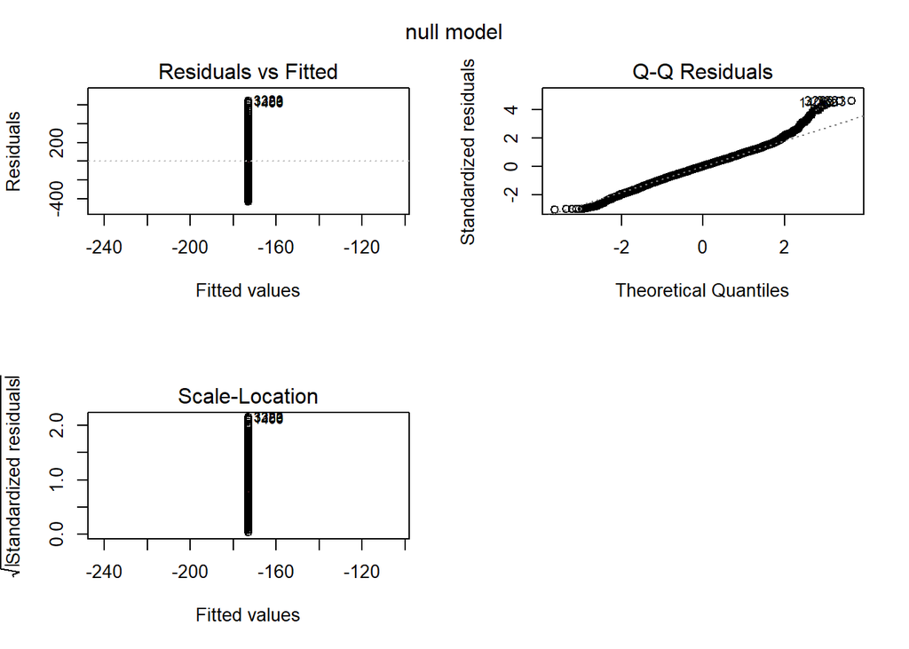

```r
mtext("null model", side = 3, line = -2, outer = TRUE)
```

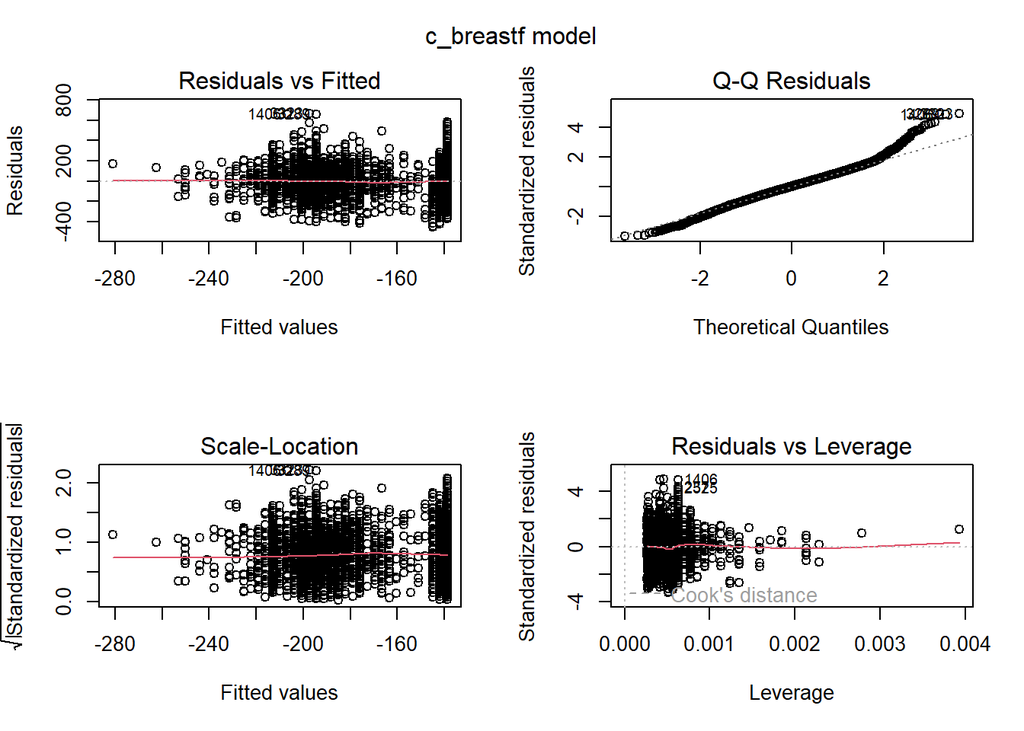

```r
plot(lm_c_breastf)
mtext("c_breastf model", side = 3, line = -2, outer = TRUE)
```

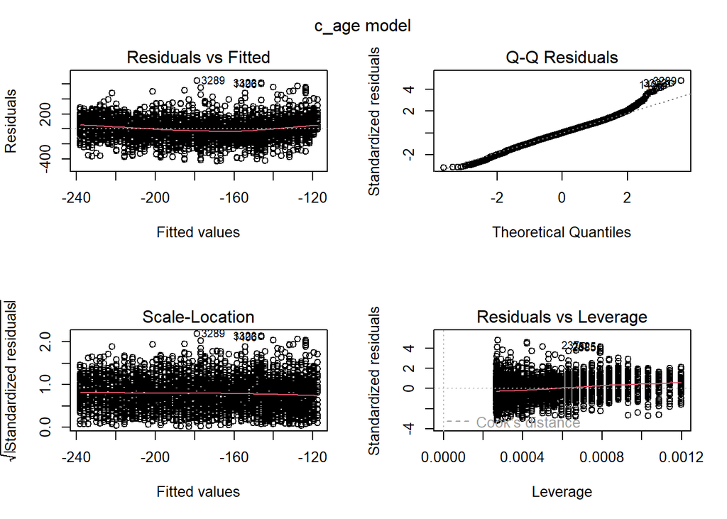

```r
plot(lm_c_age)
mtext("c_age model", side = 3, line = -2, outer = TRUE)
```

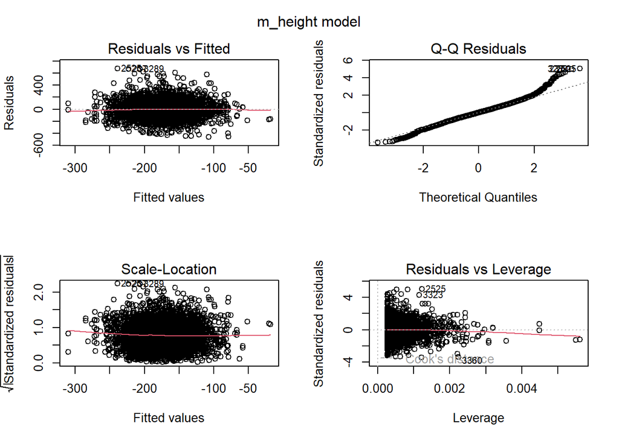

```r
plot(lm_m_height)
mtext("m_height model", side = 3, line = -2, outer = TRUE)
```

```r
par(mfrow=c(1,1))
```

The residual plots for the null model show that it has many problems. All the models show some heavy tails in the Q-Q residuals, the model with c-breastf as the only predictor shows some heteroscedasticity, and the model with c_age as the only predictor shows some non-linearity in the residuals.

Let’s try to use all the three variables.

```r
lm_all_correlated <- lm(zscore ~ c_breastf + c_age + m_height, data = train_data)

summary(lm_all_correlated)
```

```
##
## Call:
## lm(formula = zscore ~ c_breastf + c_age + m_height, data = train_data)
##
## Residuals:
##     Min      1Q  Median      3Q     Max
## -458.68  -79.72   -0.57   78.68  682.71
##
## Coefficients:
##               Estimate Std. Error t value Pr(>|t|)
## (Intercept) -1042.0210    55.5333 -18.764   <2e-16 ***
## c_breastf      -0.5467     0.3541  -1.544    0.123
## c_age          -1.8563     0.1952  -9.509   <2e-16 ***
## m_height        5.8570     0.3511  16.684   <2e-16 ***
## ---
## Signif. codes:  0 '***' 0.001 '**' 0.01 '*' 0.05 '.' 0.1 ' ' 1
##
## Residual standard error: 129.7 on 3753 degrees of freedom
## Multiple R-squared:  0.1286, Adjusted R-squared:  0.1279
## F-statistic: 184.6 on 3 and 3753 DF,  p-value: < 2.2e-16
```

```r
# Test error
predicted <- predict(lm_all_correlated, newdata = test_data)
MSE <- mean((predicted - test_data$zscore)^2)
RMSE <- sqrt(MSE)
MAE <- mean(abs(predicted - test_data$zscore))

paste("MSE: ", MSE, ", RMSE: ", RMSE, ", MAE: ", MAE)
```

```
## [1] "MSE:  17683.681660505 , RMSE:  132.980004739453 , MAE:  98.6856093834343"
```

```r
AIC <- AIC(lm_all_correlated)
BIC <- BIC(lm_all_correlated)

paste("AIC: ", round(AIC), ", BIC: ", round(BIC))
```

```
## [1] "AIC:  47225 , BIC:  47256"
```

The R-squared increased, test error and both AIC and BIC decreased, so the model has improved.

Let’s take a look at the residuals.

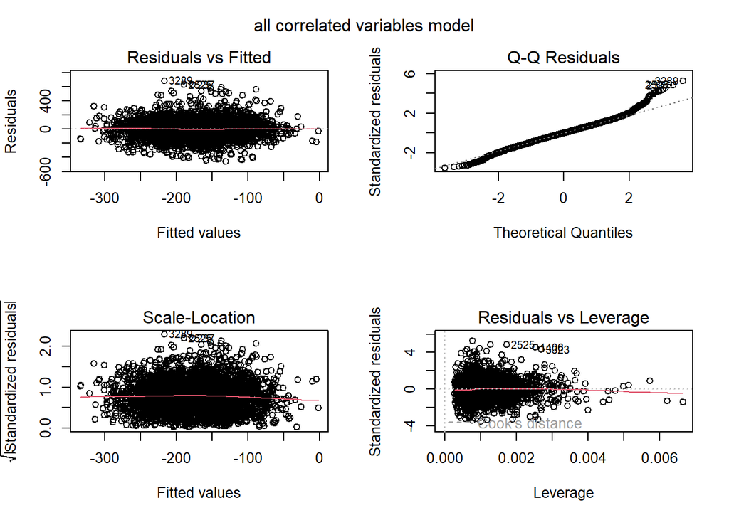

```r
par(mfrow=c(2,2))
plot(lm_all_correlated)
mtext("all correlated variables model", side = 3, line = -2, outer = TRUE)
```

```r
par(mfrow=c(1,1))
```

Except from the heavy tails in the Q-Q residuals, the model seems to be fine.

Let’s try to use all the variables as predictors.

```r
lm_all <- lm(zscore ~ ., data = train_data)

summary(lm_all)
```

```
##
## Call:
## lm(formula = zscore ~ ., data = train_data)
##
## Residuals:
##     Min      1Q  Median      3Q     Max
## -457.17  -77.52   -2.14   75.00  642.46
##
## Coefficients: (8 not defined because of singularities)
##               Estimate Std. Error t value Pr(>|t|)
## (Intercept)  -968.9270    61.3235 -15.800  < 2e-16 ***
## c_gender1     -14.2796     4.1370  -3.452 0.000563 ***
## c_breastf      -0.4689     0.3495  -1.342 0.179796
## c_age          -1.9309     0.1917 -10.071  < 2e-16 ***
## m_agebirth      0.8764     0.3155   2.778 0.005499 **
## m_height        4.8579     0.3596  13.510  < 2e-16 ***
## m_bmi           3.2776     0.6692   4.898 1.01e-06 ***
## m_education2    8.8505     5.9079   1.498 0.134195
## m_education3   24.9555     7.8043   3.198 0.001397 **
## m_education4   85.2657    17.0128   5.012 5.64e-07 ***
## m_work1        -1.8001     4.5054  -0.400 0.689526
## region2        23.7921    18.8062   1.265 0.205907
## region3       -44.5155    20.7989  -2.140 0.032397 *
## region4       -35.7719    17.5603  -2.037 0.041712 *
## region5         0.6571    13.7390   0.048 0.961858
## region6       -51.6382    19.3335  -2.671 0.007598 **
## region7       -11.0574    22.6660  -0.488 0.625691
## region8       -26.5843    25.3637  -1.048 0.294650
## region9        12.2352    27.9477   0.438 0.661566
## district13    -17.6837    18.4738  -0.957 0.338513
## district14     30.1785    22.7260   1.328 0.184284
## district15     12.4078    21.6117   0.574 0.565918
## district21    -78.4423    33.9318  -2.312 0.020845 *
## district22     33.5808    19.9748   1.681 0.092817 .
## district23     33.6583    23.9744   1.404 0.160424
## district24    -33.2035    25.4652  -1.304 0.192356
## district25    -31.2161    22.1149  -1.412 0.158170
## district26     14.7145    31.1972   0.472 0.637197
## district27     -2.0170    19.9300  -0.101 0.919393
## district28     -9.2358    26.4922  -0.349 0.727392
```

[output cut: 33 more lines]

```
## district89     29.1789    14.0083   2.083 0.037323 *
## district91     19.1189    42.5548   0.449 0.653258
## district92     43.7115    28.1132   1.555 0.120070
## district93     42.7201    25.7583   1.658 0.097302 .
## district94     12.0342    24.6571   0.488 0.625536
## district95     23.5630    27.6050   0.854 0.393396
## district97     27.5198    24.7901   1.110 0.267024
## district98          NA         NA      NA       NA
## district99          NA         NA      NA       NA
## ---
## Signif. codes:  0 '***' 0.001 '**' 0.01 '*' 0.05 '.' 0.1 ' ' 1
##
## Residual standard error: 125.5 on 3693 degrees of freedom
## Multiple R-squared:  0.1967, Adjusted R-squared:  0.183
## F-statistic: 14.35 on 63 and 3693 DF,  p-value: < 2.2e-16
```

```r
# Test error
predicted <- predict(lm_all, newdata = test_data)
MSE <- mean((predicted - test_data$zscore)^2)
RMSE <- sqrt(MSE)
MAE <- mean(abs(predicted - test_data$zscore))

paste("MSE: ", MSE, ", RMSE: ", RMSE, ", MAE: ", MAE)
```

```
## [1] "MSE:  16269.3669518422 , RMSE:  127.55142865465 , MAE:  94.5780734676383"
```

```r
AIC <- AIC(lm_all)
BIC <- BIC(lm_all)

paste("AIC: ", round(AIC), ", BIC: ", round(BIC))
```

```
## [1] "AIC:  47039 , BIC:  47444"
```

The R-squared increased, test error and AIC decreased, but BIC increased. The full model is usually not a wise choice, it’s too complex.

Let’s take a look at the residuals.

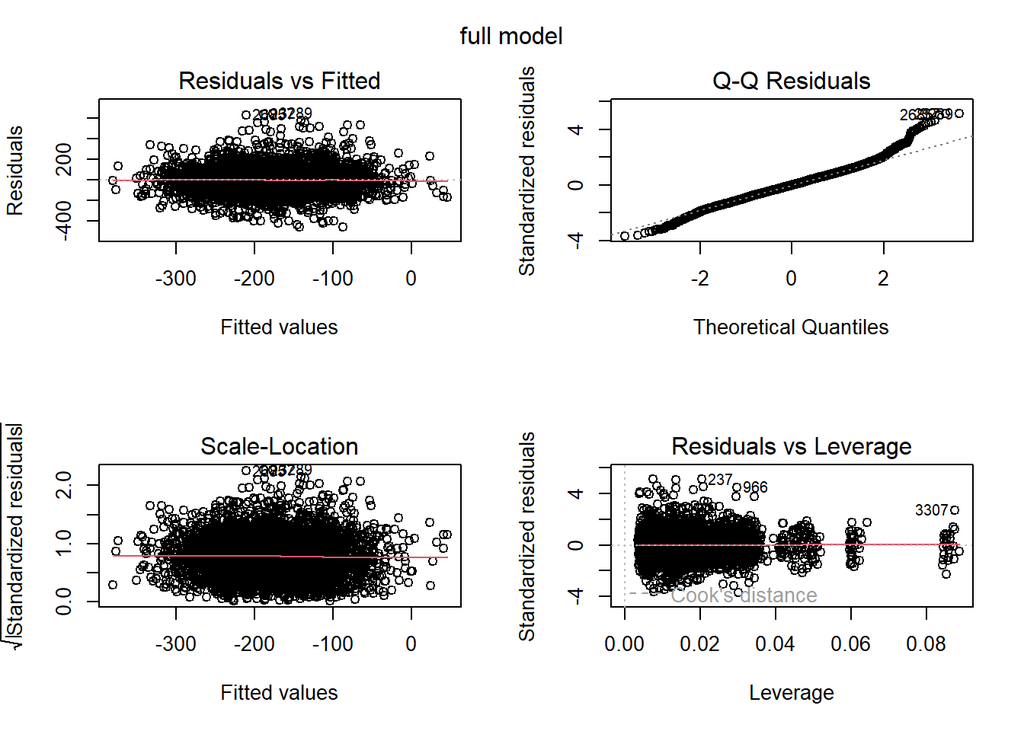

```r
par(mfrow=c(2,2))
plot(lm_all)
mtext("full model", side = 3, line = -2, outer = TRUE)
```

```r
par(mfrow=c(1,1))
```

Again, the residual plots don’t show any major problems.

Let’s try to remove the less significant predictors.

```r
# Less significant predictors are: c_breastf, m_work, district

lm_most_significant <- lm(zscore ~ . - c_breastf - m_work - district, data = train_data)

summary(lm_most_significant)
```

```
##
## Call:
## lm(formula = zscore ~ . - c_breastf - m_work - district, data = train_data)
##
## Residuals:
##     Min      1Q  Median      3Q     Max
## -465.09  -76.79   -2.27   76.41  656.20
##
## Coefficients:
##               Estimate Std. Error t value Pr(>|t|)
## (Intercept)  -980.1131    59.2148 -16.552  < 2e-16 ***
## c_gender1     -13.8062     4.1281  -3.344 0.000833 ***
## c_age          -2.1279     0.1209 -17.605  < 2e-16 ***
## m_agebirth      0.8629     0.3116   2.769 0.005643 **
## m_height        4.8709     0.3557  13.695  < 2e-16 ***
## m_bmi           3.3762     0.6563   5.145 2.82e-07 ***
## m_education2    9.3344     5.6717   1.646 0.099895 .
## m_education3   29.1610     7.4377   3.921 8.99e-05 ***
## m_education4   86.7493    16.6563   5.208 2.01e-07 ***
## region2        10.2947     8.3159   1.238 0.215812
## region3       -26.1700     9.8404  -2.659 0.007860 **
## region4       -35.8947     9.9533  -3.606 0.000315 ***
## region5        11.2586     8.9920   1.252 0.210624
## region6       -39.8332     9.6067  -4.146 3.45e-05 ***
## region7       -23.5353    11.2233  -2.097 0.036061 *
## region8         4.5650     8.8030   0.519 0.604091
## region9       -12.1704    10.6924  -1.138 0.255100
## ---
## Signif. codes:  0 '***' 0.001 '**' 0.01 '*' 0.05 '.' 0.1 ' ' 1
##
## Residual standard error: 126.1 on 3740 degrees of freedom
## Multiple R-squared:  0.179,  Adjusted R-squared:  0.1755
## F-statistic: 50.95 on 16 and 3740 DF,  p-value: < 2.2e-16
```

```r
# Test error
predicted <- predict(lm_most_significant, newdata = test_data)
MSE <- mean((predicted - test_data$zscore)^2)
RMSE <- sqrt(MSE)
MAE <- mean(abs(predicted - test_data$zscore))

paste("MSE: ", MSE, ", RMSE: ", RMSE, ", MAE: ", MAE)
```

```
## [1] "MSE:  16518.696761363 , RMSE:  128.525082226634 , MAE:  95.092539868006"
```

```r
AIC <- AIC(lm_most_significant)
BIC <- BIC(lm_most_significant)

paste("AIC: ", round(AIC), ", BIC: ", round(BIC))
```

```
## [1] "AIC:  47027 , BIC:  47139"
```

Let’s take a look at the residuals.

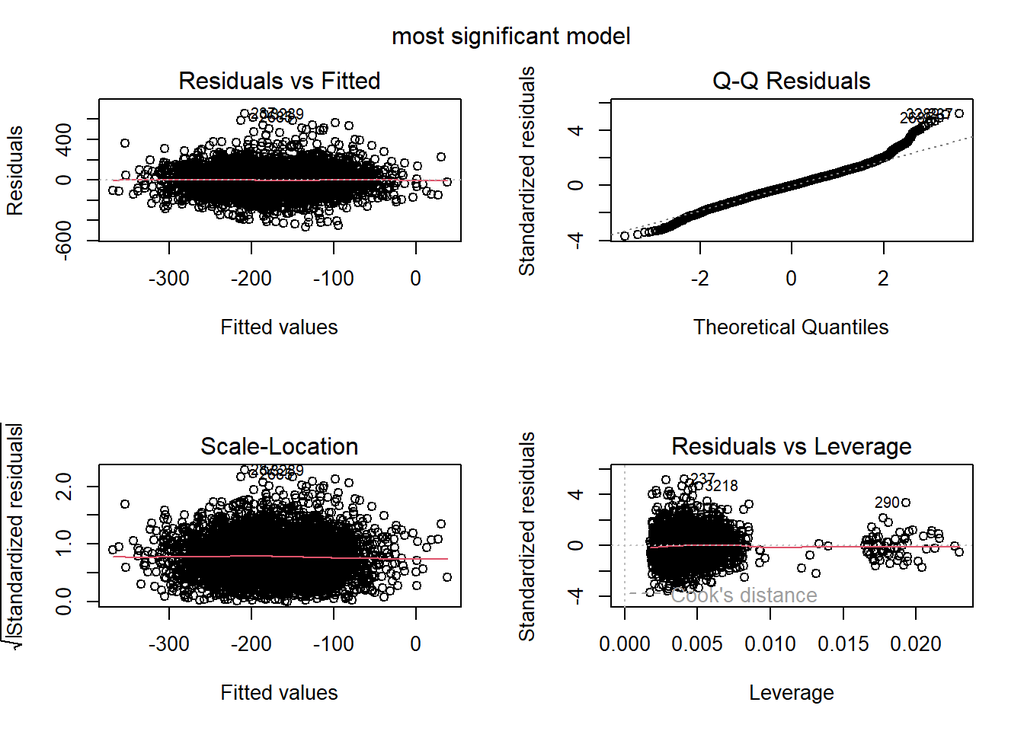

```r
par(mfrow=c(2,2))
plot(lm_most_significant)
mtext("most significant model", side = 3, line = -2, outer = TRUE)
```

```r
par(mfrow=c(1,1))
```

Except from the heavy tails in the Q-Q residuals, the model only shows some non-linearity in the residuals.

Since c_age and c_breastf are highly correlated, let’s try to introduce interaction between them.

```r
lm_interaction <- lm(zscore ~ . + c_age * c_breastf - m_work - district, data = train_data)

summary(lm_interaction)
```

```
##
## Call:
## lm(formula = zscore ~ . + c_age * c_breastf - m_work - district,
##     data = train_data)
##
## Residuals:
##     Min      1Q  Median      3Q     Max
## -461.08  -73.25   -3.00   73.32  667.93
##
## Coefficients:
##                   Estimate Std. Error t value Pr(>|t|)
## (Intercept)     -956.50892   58.28524 -16.411  < 2e-16 ***
## c_gender1        -13.64229    4.06101  -3.359 0.000789 ***
## c_breastf         -5.35268    0.55045  -9.724  < 2e-16 ***
## c_age             -4.30189    0.28436 -15.128  < 2e-16 ***
## m_agebirth         0.76264    0.30660   2.487 0.012910 *
## m_height           4.95590    0.34991  14.163  < 2e-16 ***
## m_bmi              3.34900    0.64575   5.186 2.26e-07 ***
## m_education2       8.26975    5.58126   1.482 0.138504
## m_education3      29.44488    7.31790   4.024 5.84e-05 ***
## m_education4      88.78569   16.40451   5.412 6.61e-08 ***
## region2           10.38310    8.17932   1.269 0.204366
## region3          -31.54139    9.72163  -3.244 0.001187 **
## region4          -35.51044    9.78991  -3.627 0.000290 ***
## region5           10.01673    8.84715   1.132 0.257624
## region6          -45.52756    9.46533  -4.810 1.57e-06 ***
## region7          -26.51381   11.04392  -2.401 0.016410 *
## region8            2.58308    8.66926   0.298 0.765751
## region9          -19.21824   10.54402  -1.823 0.068434 .
## c_breastf:c_age    0.20499    0.01829  11.211  < 2e-16 ***
## ---
## Signif. codes:  0 '***' 0.001 '**' 0.01 '*' 0.05 '.' 0.1 ' ' 1
##
## Residual standard error: 124 on 3738 degrees of freedom
## Multiple R-squared:  0.2061, Adjusted R-squared:  0.2023
## F-statistic: 53.92 on 18 and 3738 DF,  p-value: < 2.2e-16
```

```r
# Test error
predicted <- predict(lm_interaction, newdata = test_data)
MSE <- mean((predicted - test_data$zscore)^2)
RMSE <- sqrt(MSE)
MAE <- mean(abs(predicted - test_data$zscore))

paste("MSE: ", MSE, ", RMSE: ", RMSE, ", MAE: ", MAE)
```

```
## [1] "MSE:  16202.2354176258 , RMSE:  127.288001860449 , MAE:  92.0415555953596"
```

```r
AIC <- AIC(lm_interaction)
BIC <- BIC(lm_interaction)

paste("AIC: ", round(AIC), ", BIC: ", round(BIC))
```

```
## [1] "AIC:  46905 , BIC:  47029"
```

Test error, BIC and AIC decreased, R-squared increased. The model has improved.

Let’s take a look at the residuals.

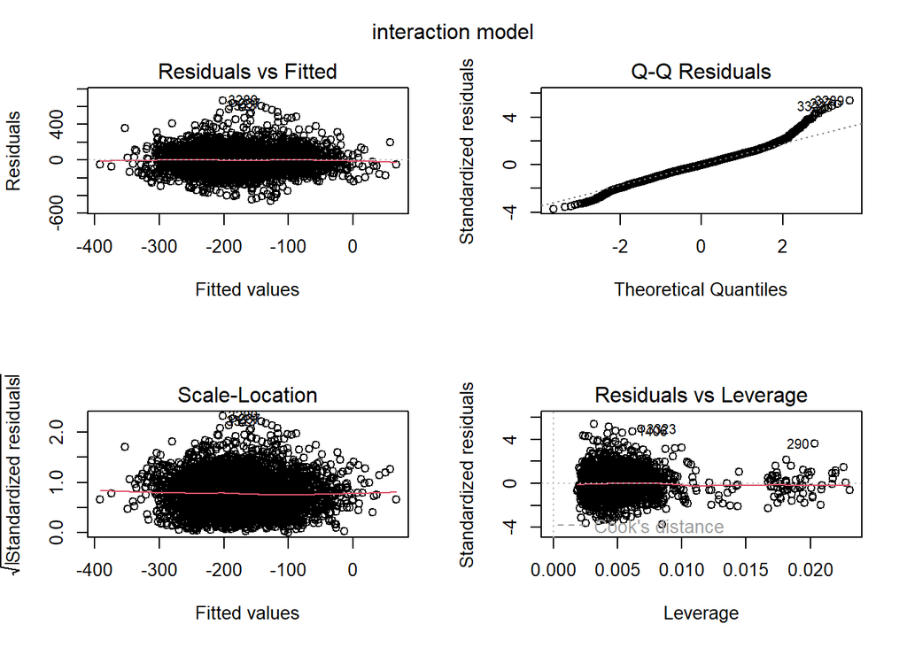

```r
par(mfrow=c(2,2))
plot(lm_interaction)
mtext("interaction model", side = 3, line = -2, outer = TRUE)
```

```r
par(mfrow=c(1,1))
```

Except from the heavy tails in the Q-Q residuals, the model seems to be fine.

Let’s try to log-transform the skewed variables.

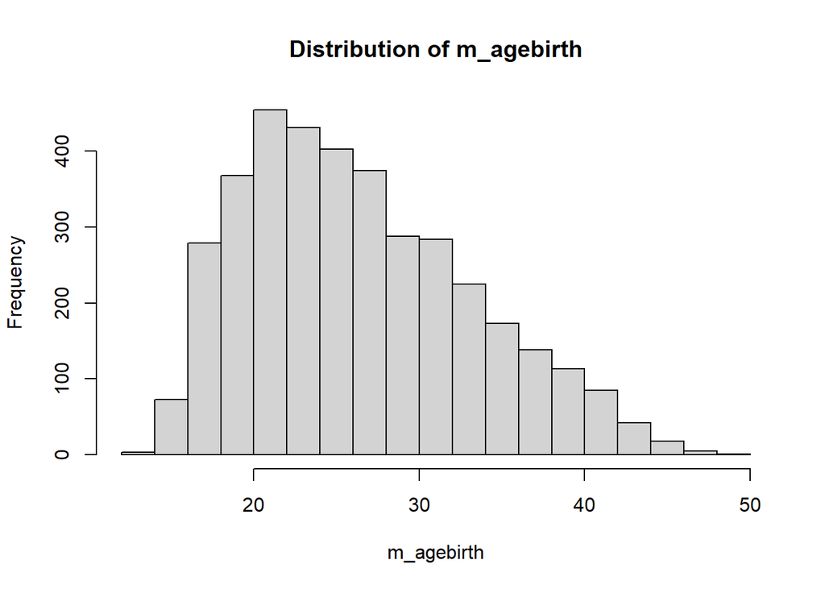

```r
# Plot the distribution of m_agebirth
hist(train_data$m_agebirth, main = "Distribution of m_agebirth", xlab = "m_agebirth")
```

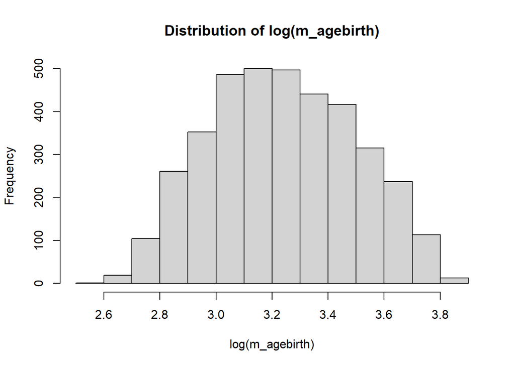

```r
# Plot the log-transform of m_agebirth
hist(log(train_data$m_agebirth), main = "Distribution of log(m_agebirth)", xlab = "log(m_agebirth)")
```

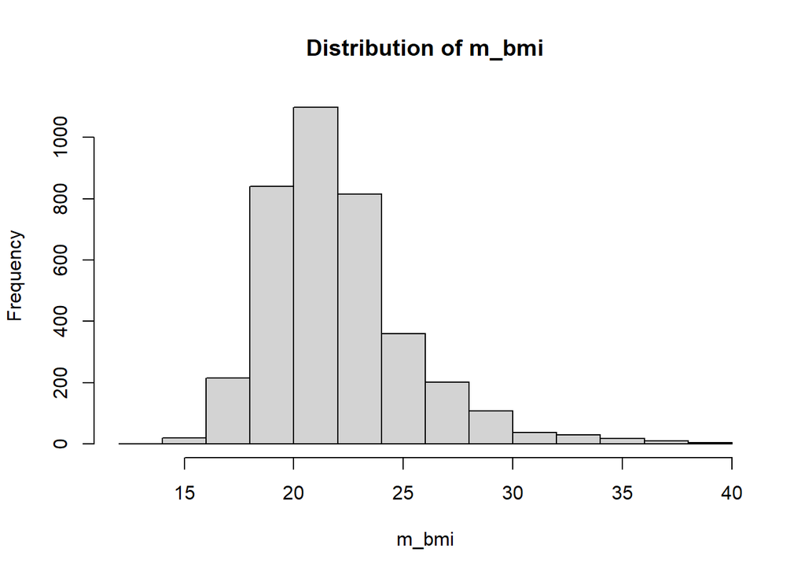

```r
# Plot the distribution of m_bmi
hist(train_data$m_bmi, main = "Distribution of m_bmi", xlab = "m_bmi")
```

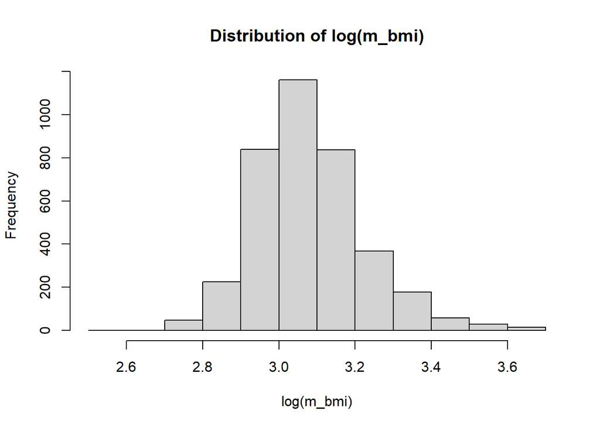

```r
# Plot the log-transform of m_bmi
hist(log(train_data$m_bmi), main = "Distribution of log(m_bmi)", xlab = "log(m_bmi)")
```

Let’s train a model with the log-transformed variables.

```r
lm_log_transform <- lm(zscore ~ . + log(m_agebirth) + log(m_bmi) - m_agebirth - m_bmi + c_age*c_breastf - m_work - district, data = train_data)

summary(lm_log_transform)
```

```
##
## Call:
## lm(formula = zscore ~ . + log(m_agebirth) + log(m_bmi) - m_agebirth -
##     m_bmi + c_age * c_breastf - m_work - district, data = train_data)
##
## Residuals:
##     Min      1Q  Median      3Q     Max
## -461.61  -73.32   -2.48   73.07  667.76
##
## Coefficients:
##                   Estimate Std. Error t value Pr(>|t|)
## (Intercept)     -1.174e+03  7.570e+01 -15.511  < 2e-16 ***
## c_gender1       -1.362e+01  4.060e+00  -3.353 0.000806 ***
## c_breastf       -5.355e+00  5.504e-01  -9.730  < 2e-16 ***
## c_age           -4.293e+00  2.843e-01 -15.100  < 2e-16 ***
## m_height         4.957e+00  3.499e-01  14.165  < 2e-16 ***
## m_education2     7.834e+00  5.564e+00   1.408 0.159203
## m_education3     2.871e+01  7.293e+00   3.936 8.42e-05 ***
## m_education4     8.804e+01  1.640e+01   5.367 8.49e-08 ***
## region2          1.052e+01  8.178e+00   1.286 0.198403
## region3         -3.145e+01  9.720e+00  -3.236 0.001224 **
## region4         -3.532e+01  9.789e+00  -3.608 0.000313 ***
## region5          1.022e+01  8.845e+00   1.155 0.248178
## region6         -4.542e+01  9.463e+00  -4.800 1.65e-06 ***
## region7         -2.621e+01  1.105e+01  -2.373 0.017698 *
## region8          2.417e+00  8.667e+00   0.279 0.780363
## region9         -1.872e+01  1.055e+01  -1.774 0.076112 .
## log(m_agebirth)  1.930e+01  8.158e+00   2.366 0.018031 *
## log(m_bmi)       8.082e+01  1.504e+01   5.374 8.17e-08 ***
## c_breastf:c_age  2.046e-01  1.828e-02  11.188  < 2e-16 ***
## ---
## Signif. codes:  0 '***' 0.001 '**' 0.01 '*' 0.05 '.' 0.1 ' ' 1
##
## Residual standard error: 124 on 3738 degrees of freedom
## Multiple R-squared:  0.2064, Adjusted R-squared:  0.2026
## F-statistic: 54.01 on 18 and 3738 DF,  p-value: < 2.2e-16
```

```r
# Test error
predicted <- predict(lm_log_transform, newdata = test_data)
MSE <- mean((predicted - test_data$zscore)^2)
RMSE <- sqrt(MSE)
MAE <- mean(abs(predicted - test_data$zscore))

paste("MSE: ", MSE, ", RMSE: ", RMSE, ", MAE: ", MAE)
```

```
## [1] "MSE:  16203.6072238366 , RMSE:  127.29339033837 , MAE:  92.0370932975288"
```

```r
AIC <- AIC(lm_log_transform)
BIC <- BIC(lm_log_transform)

paste("AIC: ", round(AIC), ", BIC: ", round(BIC))
```

```
## [1] "AIC:  46903 , BIC:  47028"
```

The model didn’t change much. Let’s take a look at the residuals.

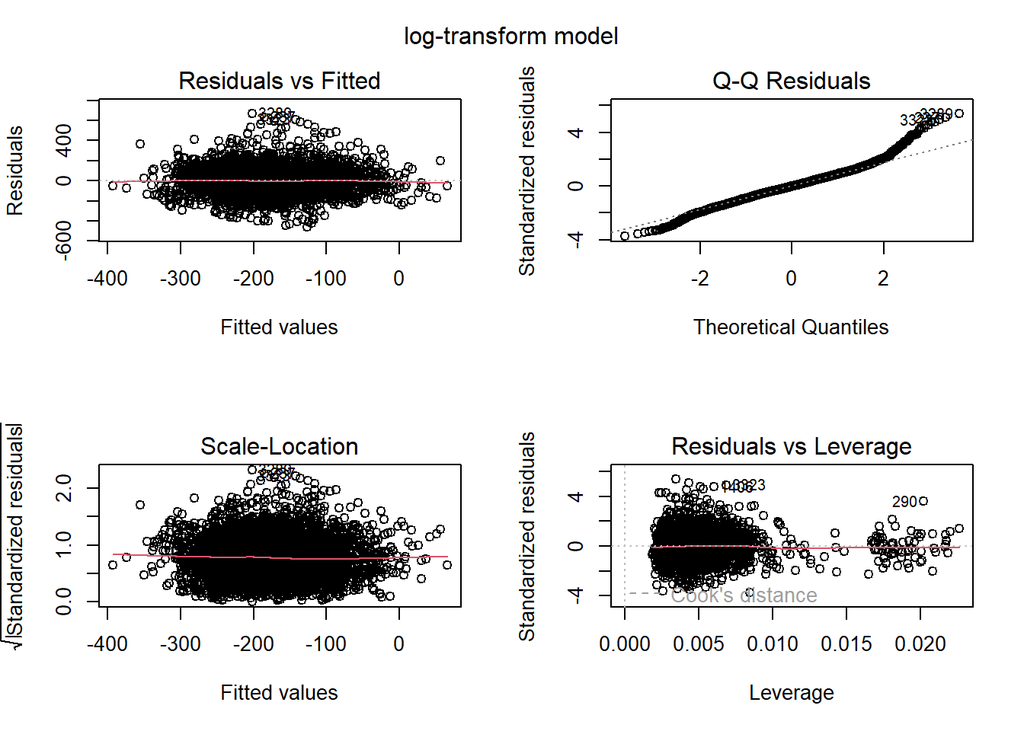

```r
par(mfrow=c(2,2))
plot(lm_log_transform)
mtext("log-transform model", side = 3, line = -2, outer = TRUE)
```

```r
par(mfrow=c(1,1))
```

Same considerations as before hold, log-transforming the skewed variables doesn’t change much.

Let’s see if the variables we’ve dropped and the ones we decided to keep are really the best ones with the step AIC.

```r
library(MASS)

test_lm <- stepAIC(lm_all, direction = "both")
```

```
## Start:  AIC=36374.98
## zscore ~ c_gender + c_breastf + c_age + m_agebirth + m_height +
##     m_bmi + m_education + m_work + region + district
##
##
## Step:  AIC=36374.98
## zscore ~ c_gender + c_breastf + c_age + m_agebirth + m_height +
##     m_bmi + m_education + m_work + district
##
##               Df Sum of Sq      RSS   AIC
## - m_work       1      2515 58192709 36373
## - c_breastf    1     28362 58218556 36375
## <none>                     58190193 36375
## - m_agebirth   1    121589 58311783 36381
## - c_gender     1    187727 58377920 36385
## - m_bmi        1    378016 58568209 36397
## - m_education  3    490794 58680987 36401
## - district    53   2390383 60580576 36420
## - c_age        1   1598086 59788280 36475
## - m_height     1   2876120 61066314 36554
##
## Step:  AIC=36373.14
## zscore ~ c_gender + c_breastf + c_age + m_agebirth + m_height +
##     m_bmi + m_education + district
##
##               Df Sum of Sq      RSS   AIC
## - c_breastf    1     28324 58221032 36373
## <none>                     58192709 36373
## + m_work       1      2515 58190193 36375
## - m_agebirth   1    119384 58312093 36379
## - c_gender     1    188631 58381340 36383
## - m_bmi        1    376006 58568715 36395
## - m_education  3    491093 58683802 36399
## - district    53   2454872 60647581 36422
## - c_age        1   1603694 59796402 36473
## - m_height     1   2873632 61066341 36552
##
## Step:  AIC=36372.97
## zscore ~ c_gender + c_age + m_agebirth + m_height + m_bmi + m_education +
##     district
##
##               Df Sum of Sq      RSS   AIC
## <none>                     58221032 36373
## + c_breastf    1     28324 58192709 36373
## + m_work       1      2477 58218556 36375
## - m_agebirth   1    119959 58340991 36379
## - c_gender     1    186312 58407345 36383
## - m_bmi        1    370620 58591652 36395
## - m_education  3    501457 58722489 36399
## - district    53   2464999 60686031 36423
## - m_height     1   2878256 61099289 36552
## - c_age        1   4907268 63128300 36675
```

It looks like the model with the lowest AIC is the one with c_gender + c_age + m_agebirth + m_height + m_bmi + m_education + district, let’s analyze the test error of this model.

```r
# Test error
predicted <- predict(test_lm, newdata = test_data)
MSE <- mean((predicted - test_data$zscore)^2)
RMSE <- sqrt(MSE)
MAE <- mean(abs(predicted - test_data$zscore))

paste("MSE: ", MSE, ", RMSE: ", RMSE, ", MAE: ", MAE)
```

```
## [1] "MSE:  16265.121572259 , RMSE:  127.534785734163 , MAE:  94.6087776890617"
```

```r
AIC <- AIC(test_lm)
BIC <- BIC(test_lm)

paste("AIC: ", round(AIC), ", BIC: ", round(BIC))
```

```
## [1] "AIC:  47037 , BIC:  47429"
```

Step AIC suggests to drop m_work and c_breastf, but the best model we found so far has c_breastf and doesn’t have m_work and district. Test error and both AIC and BIC are lower with the model we found “manually”.

Since c_breastf has a strange pattern, let’s try to cut the values that are not 0, 1 or 2 to regularize it.

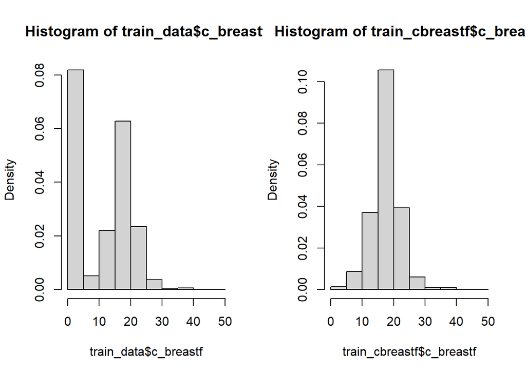

```r
train_cbreastf <- train_data[train_data$c_breastf != 0 & train_data$c_breastf != 1 & train_data$c_breastf != 2,]

par(mfrow=c(1,2))
hist(train_data$c_breastf, probability = TRUE, breaks = 15)
hist(train_cbreastf$c_breastf, probability = TRUE, breaks = 15)
```

Now the distribution is regular, but sometimes removing many rows from a dataset can be harmful, for this reason we decided to mantain the original dataset. Instead, it may be better to assign the value 0 to all the value of c_breastf that are 0, 1 or 2, and assign 1 otherwise.

```r
train_data_cat <- train_data
test_data_cat <- test_data
train_data_cat$c_breastf <- ifelse(train_data$c_breastf == 0 | train_data$c_breastf == 1 | train_data$c_breastf == 2, 0, 1)
test_data_cat$c_breastf <- ifelse(test_data$c_breastf == 0 | test_data$c_breastf == 1 | test_data$c_breastf == 2, 0, 1)
train_data_cat$c_breastf <- as.factor(train_data_cat$c_breastf)
test_data_cat$c_breastf <- as.factor(test_data_cat$c_breastf)
```

```r
lm_interaction2_cat <- lm(zscore ~ . + c_age * c_breastf - m_work - district, data = train_data_cat)
summary(lm_interaction2_cat)
```

```
##
## Call:
## lm(formula = zscore ~ . + c_age * c_breastf - m_work - district,
##     data = train_data_cat)
##
## Residuals:
##     Min      1Q  Median      3Q     Max
## -437.98  -71.10   -3.16   69.62  668.66
##
## Coefficients:
##                   Estimate Std. Error t value Pr(>|t|)
## (Intercept)      -902.9327    57.3126 -15.755  < 2e-16 ***
## c_gender1         -14.1325     3.9820  -3.549 0.000391 ***
## c_breastf1       -133.1843    10.2848 -12.950  < 2e-16 ***
## c_age              -8.6593     0.4398 -19.689  < 2e-16 ***
## m_agebirth          1.0497     0.3012   3.486 0.000497 ***
## m_height            4.8338     0.3431  14.089  < 2e-16 ***
## m_bmi               2.9514     0.6342   4.653 3.38e-06 ***
## m_education2        9.6723     5.4710   1.768 0.077156 .
## m_education3       28.7693     7.1761   4.009 6.22e-05 ***
## m_education4       81.6350    16.0735   5.079 3.98e-07 ***
## region2            10.3963     8.0212   1.296 0.195019
## region3           -25.6889     9.4918  -2.706 0.006832 **
## region4           -34.3143     9.6011  -3.574 0.000356 ***
## region5            13.4206     8.6743   1.547 0.121907
## region6           -39.9562     9.2709  -4.310 1.68e-05 ***
## region7           -19.0610    10.8450  -1.758 0.078900 .
## region8             8.4035     8.4945   0.989 0.322587
## region9            -6.9965    10.3307  -0.677 0.498287
## c_breastf1:c_age    8.2123     0.4894  16.780  < 2e-16 ***
## ---
## Signif. codes:  0 '***' 0.001 '**' 0.01 '*' 0.05 '.' 0.1 ' ' 1
##
## Residual standard error: 121.6 on 3738 degrees of freedom
## Multiple R-squared:  0.2365, Adjusted R-squared:  0.2329
## F-statistic: 64.34 on 18 and 3738 DF,  p-value: < 2.2e-16
```

```r
predicted <- predict(lm_interaction2_cat, newdata = test_data_cat)
MSE <- mean((predicted - test_data_cat$zscore)^2)
RMSE <- sqrt(MSE)
MAE <- mean(abs(predicted - test_data_cat$zscore))

paste("MSE: ", MSE, ", RMSE: ", RMSE, ", MAE: ", MAE)
```

```
## [1] "MSE:  15443.9263729793 , RMSE:  124.273594834057 , MAE:  90.2819516143078"
```

```r
AIC <- AIC(lm_interaction2_cat)
BIC <- BIC(lm_interaction2_cat)

paste("AIC: ", round(AIC), ", BIC: ", round(BIC))
```

```
## [1] "AIC:  46758 , BIC:  46882"
```

The model has improved by considering the categorical version of c_breastf.

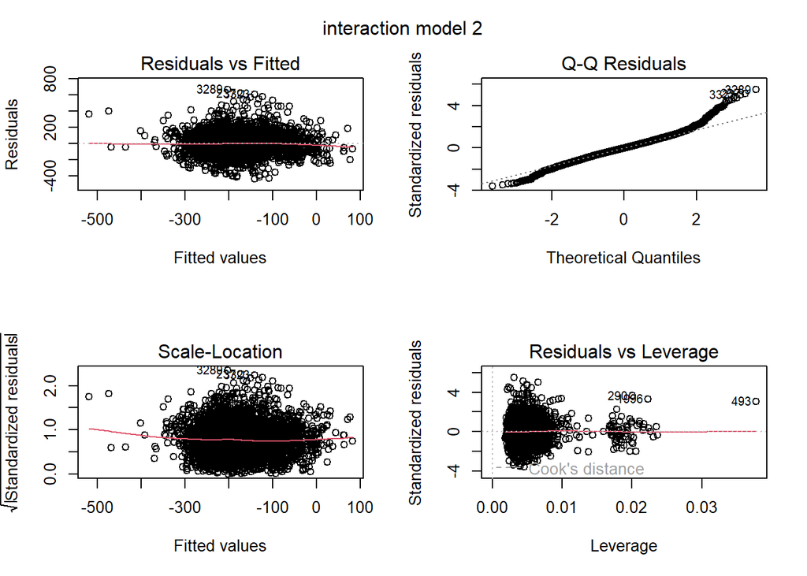

```r
par(mfrow=c(2,2))
plot(lm_interaction2_cat)
mtext("interaction model 2", side = 3, line = -2, outer = TRUE)
```

```r
par(mfrow=c(1,1))
```

Nothing new here.

Let’s analyze the vif of the best linear model found.

```r
library(car)
vif(lm_interaction2_cat)
```

```
## there are higher-order terms (interactions) in this model
## consider setting type = 'predictor'; see ?vif
```

```
##                      GVIF Df GVIF^(1/(2*Df))
## c_gender         1.005732  1        1.002862
## c_breastf        6.470424  1        2.543703
## c_age           14.361393  1        3.789643
## m_agebirth       1.080258  1        1.039355
## m_height         1.086352  1        1.042282
## m_bmi            1.132135  1        1.064018
## m_education      1.213102  3        1.032721
## region           1.297228  8        1.016397
## c_breastf:c_age 26.623500  1        5.159797
```

Let’s try to remove interaction terms, c_breastf and c_age.

```r
lm_interaction2_vif <- lm(zscore ~ . - c_age - c_breastf - m_work - district, data = train_data)
summary(lm_interaction2_vif)
```

```
##
## Call:
## lm(formula = zscore ~ . - c_age - c_breastf - m_work - district,
##     data = train_data)
##
## Residuals:
##     Min      1Q  Median      3Q     Max
## -459.72  -79.73   -2.59   77.33  700.16
##
## Coefficients:
##                Estimate Std. Error t value Pr(>|t|)
## (Intercept)  -1010.1136    61.5857 -16.402  < 2e-16 ***
## c_gender1      -12.0546     4.2940  -2.807 0.005021 **
## m_agebirth       1.0601     0.3240   3.272 0.001077 **
## m_height         4.7339     0.3700  12.795  < 2e-16 ***
## m_bmi            2.6182     0.6813   3.843 0.000124 ***
## m_education2    13.2437     5.8967   2.246 0.024766 *
## m_education3    33.2238     7.7350   4.295 1.79e-05 ***
## m_education4    89.8178    17.3295   5.183 2.30e-07 ***
## region2         11.7173     8.6520   1.354 0.175729
## region3        -22.8484    10.2367  -2.232 0.025673 *
## region4        -33.3349    10.3550  -3.219 0.001296 **
## region5         15.2357     9.3530   1.629 0.103403
## region6        -40.1897     9.9955  -4.021 5.91e-05 ***
## region7        -19.1339    11.6747  -1.639 0.101313
## region8          5.2253     9.1592   0.570 0.568376
## region9        -13.8867    11.1247  -1.248 0.212006
## ---
## Signif. codes:  0 '***' 0.001 '**' 0.01 '*' 0.05 '.' 0.1 ' ' 1
##
## Residual standard error: 131.2 on 3741 degrees of freedom
## Multiple R-squared:  0.1109, Adjusted R-squared:  0.1074
## F-statistic: 31.12 on 15 and 3741 DF,  p-value: < 2.2e-16
```

```r
predicted <- predict(lm_interaction2_vif, newdata = test_data)
MSE <- mean((predicted - test_data$zscore)^2)
RMSE <- sqrt(MSE)
MAE <- mean(abs(predicted - test_data$zscore))

paste("MSE: ", MSE, ", RMSE: ", RMSE, ", MAE: ", MAE)
```

```
## [1] "MSE:  17582.281428946 , RMSE:  132.598195421152 , MAE:  98.2816709608695"
```

```r
AIC <- AIC(lm_interaction2_vif)
BIC <- BIC(lm_interaction2_vif)

paste("AIC: ", round(AIC), ", BIC: ", round(BIC))
```

```
## [1] "AIC:  47324 , BIC:  47430"
```

The test error worsens, so we will keep the previous model, even tho there is some evidence of multicollinearity.

# Polynomial Regression

Let’s try to add polynomials of degree 2 to the best model found so far.

```r
lm_polynomials2 <- lm(zscore ~ . + I(c_breastf^2) + I(c_age^2)+ I(m_agebirth^2) + I(m_height^2) + I(m_bmi^2) + c_age*c_breastf + I((c_age*c_breastf)^2) - m_work - district, data = train_data)

summary(lm_polynomials2)
```

```
##
## Call:
## lm(formula = zscore ~ . + I(c_breastf^2) + I(c_age^2) + I(m_agebirth^2) +
##     I(m_height^2) + I(m_bmi^2) + c_age * c_breastf + I((c_age *
##     c_breastf)^2) - m_work - district, data = train_data)
##
## Residuals:
##     Min      1Q  Median      3Q     Max
## -435.98  -72.87   -2.78   70.53  672.58
##
## Coefficients:
##                            Estimate Std. Error t value Pr(>|t|)
## (Intercept)              -2.293e+03  8.990e+02  -2.550 0.010805 *
## c_gender1                -1.438e+01  3.955e+00  -3.637 0.000280 ***
## c_breastf                 3.963e+00  1.932e+00   2.051 0.040315 *
## c_age                    -1.281e+01  6.611e-01 -19.378  < 2e-16 ***
## m_agebirth               -1.619e+00  2.152e+00  -0.752 0.451809
## m_height                  2.212e+01  1.139e+01   1.941 0.052320 .
## m_bmi                     9.243e+00  4.937e+00   1.872 0.061274 .
## m_education2              8.787e+00  5.476e+00   1.605 0.108623
## m_education3              2.914e+01  7.202e+00   4.046 5.32e-05 ***
## m_education4              8.502e+01  1.603e+01   5.303 1.20e-07 ***
## region2                   1.191e+01  7.969e+00   1.494 0.135187
## region3                  -2.261e+01  9.524e+00  -2.375 0.017622 *
## region4                  -3.274e+01  9.543e+00  -3.431 0.000609 ***
## region5                   1.478e+01  8.629e+00   1.713 0.086857 .
## region6                  -3.847e+01  9.228e+00  -4.169 3.13e-05 ***
## region7                  -1.757e+01  1.078e+01  -1.630 0.103144
## region8                   8.681e+00  8.460e+00   1.026 0.304876
## region9                  -2.797e+00  1.040e+01  -0.269 0.788016
## I(c_breastf^2)           -1.256e-01  6.360e-02  -1.976 0.048280 *
## I(c_age^2)                1.550e-01  1.389e-02  11.153  < 2e-16 ***
## I(m_agebirth^2)           4.892e-02  3.774e-02   1.296 0.194981
## I(m_height^2)            -5.450e-02  3.599e-02  -1.515 0.129980
## I(m_bmi^2)               -1.343e-01  1.015e-01  -1.323 0.185954
## I((c_age * c_breastf)^2) -4.905e-05  2.595e-05  -1.891 0.058749 .
## c_breastf:c_age           1.048e-01  5.885e-02   1.781 0.075060 .
## ---
## Signif. codes:  0 '***' 0.001 '**' 0.01 '*' 0.05 '.' 0.1 ' ' 1
##
## Residual standard error: 120.7 on 3732 degrees of freedom
## Multiple R-squared:  0.2492, Adjusted R-squared:  0.2443
## F-statistic:  51.6 on 24 and 3732 DF,  p-value: < 2.2e-16
```

```r
# Test error
predicted <- predict(lm_polynomials2, newdata = test_data)
MSE <- mean((predicted - test_data$zscore)^2)
RMSE <- sqrt(MSE)
MAE <- mean(abs(predicted - test_data$zscore))

paste("MSE: ", MSE, ", RMSE: ", RMSE, ", MAE: ", MAE)
```

```
## [1] "MSE:  15389.8633723995 , RMSE:  124.055888100483 , MAE:  90.4316301507427"
```

```r
AIC <- AIC(lm_polynomials2)
BIC <- BIC(lm_polynomials2)

paste("AIC: ", round(AIC), ", BIC: ", round(BIC))
```

```
## [1] "AIC:  46707 , BIC:  46869"
```

R-squared increased, test error, AIC and BIC decreased, the model has improved. It seems that there is some non-linearity in the data that is better captured by the polynomials of degree 2.

Let’s take a look at the residuals.

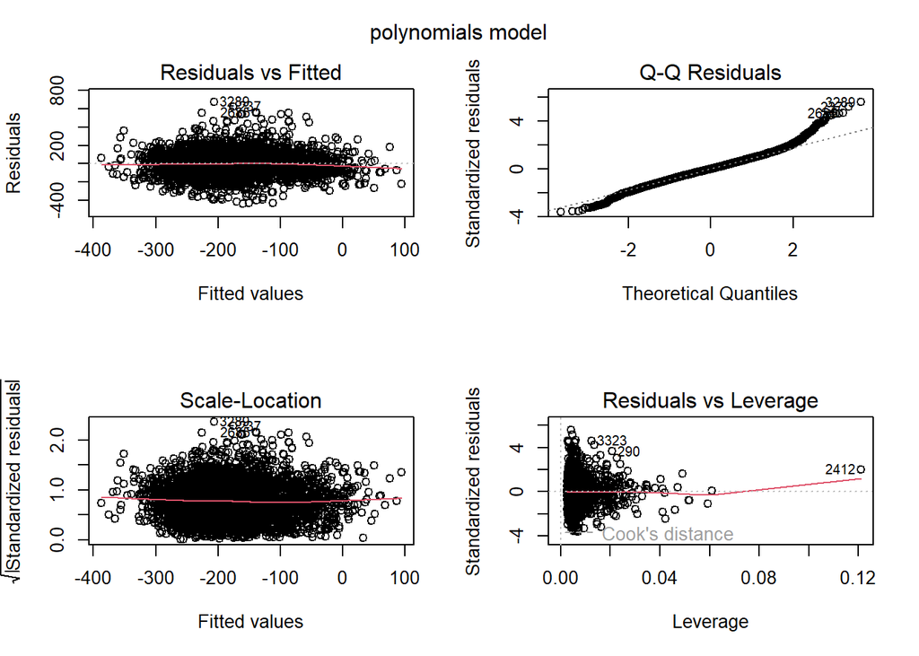

```r
par(mfrow=c(2,2))
plot(lm_polynomials2)
mtext("polynomials model", side = 3, line = -2, outer = TRUE)
```

```r
par(mfrow=c(1,1))
```

Except for the heavy tails in the Q-Q residuals, the model seems to be fine.

Let’s try to add polynomials of degree 3.

```r
lm_polynomials3 <- lm(zscore ~ . + I(c_breastf^2) + I(c_breastf^3) + I(c_age^2) + I(c_age^3) + I(m_agebirth^2) +  I(m_agebirth^3) + I(m_height^2) + I(m_height^3) + I(m_bmi^2) + I(m_bmi^3) + c_age*c_breastf + I((c_age*c_breastf)^2) + I((c_age*c_breastf)^3) - m_work - district, data = train_data)

summary(lm_polynomials3)
```

```
##
## Call:
## lm(formula = zscore ~ . + I(c_breastf^2) + I(c_breastf^3) + I(c_age^2) +
##     I(c_age^3) + I(m_agebirth^2) + I(m_agebirth^3) + I(m_height^2) +
##     I(m_height^3) + I(m_bmi^2) + I(m_bmi^3) + c_age * c_breastf +
##     I((c_age * c_breastf)^2) + I((c_age * c_breastf)^3) - m_work -
##     district, data = train_data)
##
## Residuals:
##     Min      1Q  Median      3Q     Max
## -437.96  -71.76   -2.94   70.36  677.91
##
## Coefficients:
##                            Estimate Std. Error t value Pr(>|t|)
## (Intercept)              -1.523e+03  1.151e+04  -0.132 0.894797
## c_gender1                -1.435e+01  3.953e+00  -3.629 0.000288 ***
## c_breastf                 5.238e+00  4.632e+00   1.131 0.258193
## c_age                    -1.569e+01  1.463e+00 -10.723  < 2e-16 ***
## m_agebirth                2.093e+01  1.107e+01   1.891 0.058667 .
## m_height                  4.441e+00  2.176e+02   0.020 0.983722
## m_bmi                     4.245e+00  3.095e+01   0.137 0.890919
## m_education2              9.978e+00  5.491e+00   1.817 0.069245 .
## m_education3              2.951e+01  7.212e+00   4.091 4.38e-05 ***
## m_education4              8.474e+01  1.604e+01   5.285 1.33e-07 ***
## region2                   1.164e+01  7.979e+00   1.458 0.144880
## region3                  -2.092e+01  9.540e+00  -2.193 0.028359 *
## region4                  -3.224e+01  9.538e+00  -3.380 0.000732 ***
## region5                   1.516e+01  8.635e+00   1.756 0.079202 .
## region6                  -3.818e+01  9.228e+00  -4.137 3.59e-05 ***
## region7                  -1.708e+01  1.078e+01  -1.585 0.113093
## region8                   9.386e+00  8.458e+00   1.110 0.267231
## region9                  -2.927e+00  1.041e+01  -0.281 0.778622
## I(c_breastf^2)           -2.026e-01  2.828e-01  -0.716 0.473928
## I(c_breastf^3)            1.356e-03  5.472e-03   0.248 0.804351
## I(c_age^2)                2.846e-01  7.016e-02   4.057 5.07e-05 ***
## I(c_age^3)               -1.430e-03  7.457e-04  -1.917 0.055287 .
## I(m_agebirth^2)          -7.641e-01  3.932e-01  -1.943 0.052043 .
## I(m_agebirth^3)           9.328e-03  4.492e-03   2.077 0.037913 *
## I(m_height^2)             5.941e-02  1.373e+00   0.043 0.965500
## I(m_height^3)            -2.447e-04  2.886e-03  -0.085 0.932456
## I(m_bmi^2)                5.139e-02  1.241e+00   0.041 0.966966
## I(m_bmi^3)               -2.176e-03  1.620e-02  -0.134 0.893120
## I((c_age * c_breastf)^2) -1.039e-04  1.302e-04  -0.798 0.425013
## I((c_age * c_breastf)^3)  3.141e-08  4.679e-08   0.671 0.502102
## c_breastf:c_age           1.078e-01  1.398e-01   0.771 0.440592
## ---
## Signif. codes:  0 '***' 0.001 '**' 0.01 '*' 0.05 '.' 0.1 ' ' 1
##
## Residual standard error: 120.6 on 3726 degrees of freedom
## Multiple R-squared:  0.2519, Adjusted R-squared:  0.2459
## F-statistic: 41.83 on 30 and 3726 DF,  p-value: < 2.2e-16
```

```r
# Test error
predicted <- predict(lm_polynomials3, newdata = test_data)
MSE <- mean((predicted - test_data$zscore)^2)
RMSE <- sqrt(MSE)
MAE <- mean(abs(predicted - test_data$zscore))

paste("MSE: ", MSE, ", RMSE: ", RMSE, ", MAE: ", MAE)
```

```
## [1] "MSE:  15239.8496918923 , RMSE:  123.449786115215 , MAE:  90.0925176148342"
```

```r
AIC <- AIC(lm_polynomials3)
BIC <- BIC(lm_polynomials3)

paste("AIC: ", round(AIC), ", BIC: ", round(BIC))
```

```
## [1] "AIC:  46705 , BIC:  46905"
```

The model didn’t change much from the previous one, and it’s more complex.

Let’s take a look at the residuals.

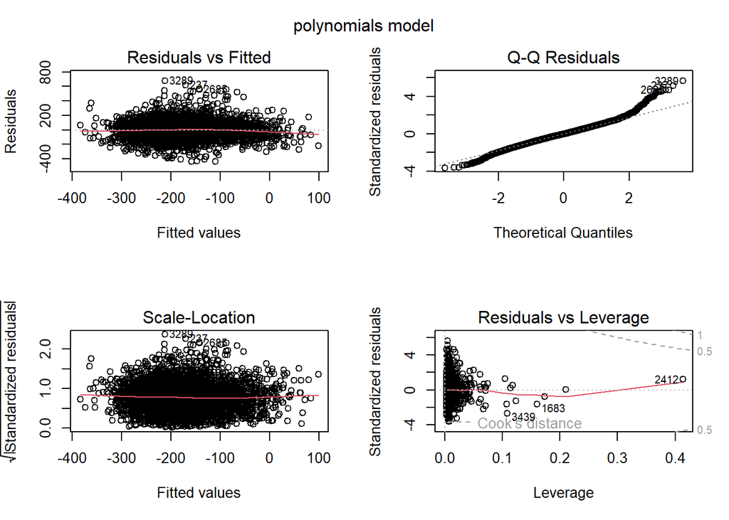

```r
par(mfrow=c(2,2))
plot(lm_polynomials3)
mtext("polynomials model", side = 3, line = -2, outer = TRUE)
```

```r
par(mfrow=c(1,1))
```

The same considerations as before hold also here.

Let’s again test the step AIC.

```r
# Modify the data to include the polynomials of degree 2
train_data_polynomials2 <- cbind(train_data, c_breastf2 = I(train_data$c_breastf^2), c_age2 = I(train_data$c_age^2), m_agebirth2 = I(train_data$m_agebirth^2), m_height2 = I(train_data$m_height^2), m_bmi2 = I(train_data$m_bmi^2), c_age_x_breastf = train_data$c_age*train_data$c_breastf, c_age_x_breastf2 = I((train_data$c_age*train_data$c_breastf)^2))

test_data_polynomials2 <- cbind(test_data, c_breastf2 = I(test_data$c_breastf^2), c_age2 = I(test_data$c_age^2), m_agebirth2 = I(test_data$m_agebirth^2), m_height2 = I(test_data$m_height^2), m_bmi2 = I(test_data$m_bmi^2), c_age_x_breastf = test_data$c_age*test_data$c_breastf, c_age_x_breastf2 = I((test_data$c_age*test_data$c_breastf)^2))

test_polynomials2 <- stepAIC(lm(zscore ~ . - m_work - district, data = train_data_polynomials2), direction = "both")
```

```
## Start:  AIC=36043.3
## zscore ~ (c_gender + c_breastf + c_age + m_agebirth + m_height +
##     m_bmi + m_education + m_work + region + district + c_breastf2 +
##     c_age2 + m_agebirth2 + m_height2 + m_bmi2 + c_age_x_breastf +
##     c_age_x_breastf2) - m_work - district
##
##                    Df Sum of Sq      RSS   AIC
## - m_agebirth        1      8252 54399122 36042
## - m_agebirth2       1     24487 54415357 36043
## - m_bmi2            1     25505 54416375 36043
## <none>                          54390870 36043
## - m_height2         1     33430 54424300 36044
## - c_age_x_breastf   1     46208 54437078 36044
## - m_bmi             1     51078 54441948 36045
## - c_age_x_breastf2  1     52096 54442966 36045
## - m_height          1     54914 54445784 36045
## - c_breastf2        1     56880 54447750 36045
## - c_breastf         1     61321 54452191 36046
## - c_gender          1    192743 54583613 36055
## - m_education       3    589876 54980746 36078
## - region            8   1200367 55591237 36109
## - c_age2            1   1812943 56203813 36164
## - c_age             1   5472786 59863656 36401
##
## Step:  AIC=36041.87
## zscore ~ c_gender + c_breastf + c_age + m_height + m_bmi + m_education +
##     region + c_breastf2 + c_age2 + m_agebirth2 + m_height2 +
##     m_bmi2 + c_age_x_breastf + c_age_x_breastf2
##
##                    Df Sum of Sq      RSS   AIC
## - m_bmi2            1     24815 54423938 36042
## <none>                          54399122 36042
## - m_height2         1     33481 54432603 36042
## - c_age_x_breastf   1     45674 54444796 36043
## + m_agebirth        1      8252 54390870 36043
## - m_bmi             1     49712 54448834 36043
## - c_age_x_breastf2  1     51857 54450980 36043
## - m_height          1     54919 54454041 36044
## - c_breastf2        1     57093 54456216 36044
## - c_breastf         1     61857 54460979 36044
```

[output cut: 14 more lines]

```
## + m_bmi2            1     24815 54399122 36042
## - m_height2         1     37847 54461785 36042
## - c_age_x_breastf   1     45936 54469874 36043
## + m_agebirth        1      7562 54416375 36043
## - c_age_x_breastf2  1     52637 54476575 36043
## - c_breastf2        1     56468 54480406 36043
## - m_height          1     60532 54484469 36044
## - c_breastf         1     62234 54486172 36044
## - c_gender          1    194567 54618505 36053
## - m_agebirth2       1    220466 54644404 36055
## - m_bmi             1    273628 54697565 36058
## - m_education       3    588265 55012203 36076
## - region            8   1185116 55609054 36107
## - c_age2            1   1831068 56255006 36164
## - c_age             1   5519252 59943189 36402
```

Let’s analyze the test error of the model found by step AIC.

```r
predicted <- predict(test_polynomials2, newdata = test_data_polynomials2)
MSE <- mean((predicted - test_data$zscore)^2)
RMSE <- sqrt(MSE)
MAE <- mean(abs(predicted - test_data$zscore))

paste("MSE: ", MSE, ", RMSE: ", RMSE, ", MAE: ", MAE)
```

```
## [1] "MSE:  15358.4294037318 , RMSE:  123.929130569579 , MAE:  90.2664430431696"
```

```r
AIC <- AIC(test_polynomials2)
BIC <- BIC(test_polynomials2)

paste("AIC: ", round(AIC), ", BIC: ", round(BIC))
```

```
## [1] "AIC:  46705 , BIC:  46855"
```

The model found by step AIC is slightly better than the previous polynomial regression with degree 2, and it suggests to discard m_agebirth and to avoid squaring m_bmi, it also maintains the predictors that were previously dropped.

Let’s analyze the residual plots of this model.

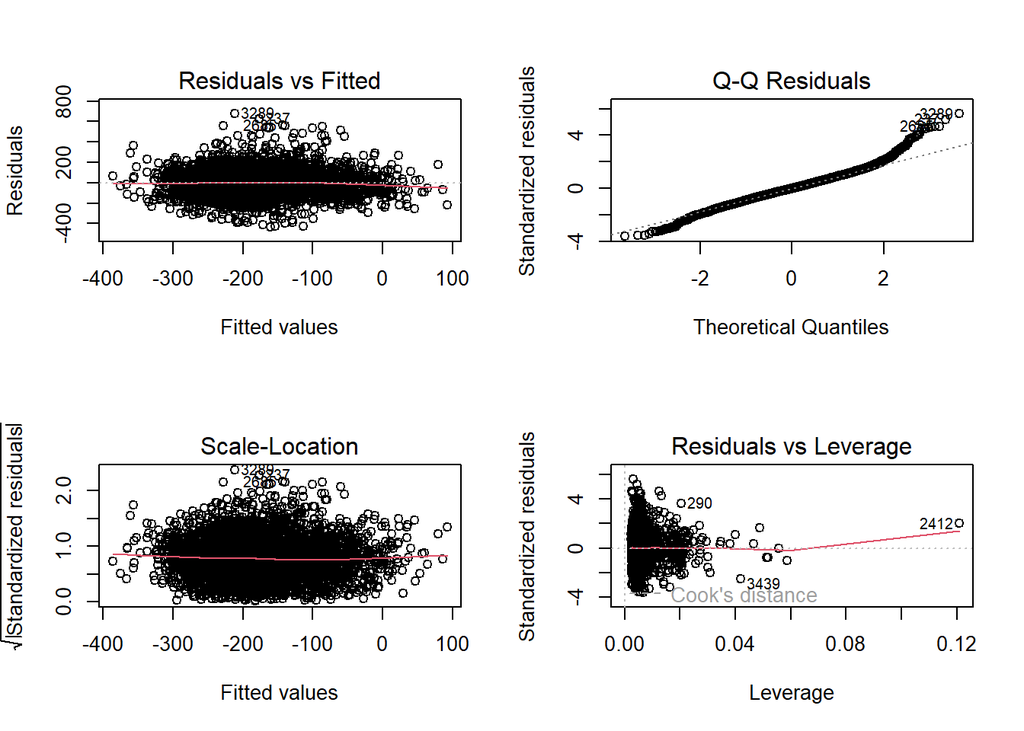

```r
par(mfrow=c(2,2))

plot(test_polynomials2)
```

Nothing new to say about the residual plots.

Let’s analyze the multicollinearity of the best linear (polynomial) regression model found so far.

```r
library(car)
vif(test_polynomials2)
```

```
##                         GVIF Df GVIF^(1/(2*Df))
## c_gender            1.007074  1        1.003531
## c_breastf          85.451357  1        9.243990
## c_age              32.867752  1        5.733040
## m_height         1210.308919  1       34.789494
## m_bmi               1.131682  1        1.063805
## m_education         1.230882  3        1.035228
## region              1.394366  8        1.020995
## c_breastf2         50.900247  1        7.134441
## c_age2             51.229892  1        7.157506
## m_agebirth2         1.091813  1        1.044898
## m_height2        1209.013518  1       34.770872
## c_age_x_breastf   152.418255  1       12.345779
## c_age_x_breastf2   40.621717  1        6.373517
```

```r
lm_polynomials2_gvif <- lm(zscore ~ c_gender + c_age + m_bmi + m_education +
    region + c_breastf + m_agebirth2, data = train_data_polynomials2)
summary(lm_polynomials2_gvif)
```

```
##
## Call:
## lm(formula = zscore ~ c_gender + c_age + m_bmi + m_education +
##     region + c_breastf + m_agebirth2, data = train_data_polynomials2)
##
## Residuals:
##     Min      1Q  Median      3Q     Max
## -467.62  -80.63   -1.15   79.16  631.22
##
## Coefficients:
##                Estimate Std. Error t value Pr(>|t|)
## (Intercept)  -1.967e+02  1.754e+01 -11.218  < 2e-16 ***
## c_gender1    -1.373e+01  4.230e+00  -3.245  0.00118 **
## c_age        -1.865e+00  1.956e-01  -9.531  < 2e-16 ***
## m_bmi         2.934e+00  6.705e-01   4.376 1.24e-05 ***
## m_education2  1.498e+01  5.815e+00   2.576  0.01005 *
## m_education3  4.091e+01  7.601e+00   5.382 7.82e-08 ***
## m_education4  1.044e+02  1.703e+01   6.129 9.77e-10 ***
## region2       1.335e+01  8.515e+00   1.567  0.11715
## region3      -3.157e+01  1.010e+01  -3.127  0.00178 **
## region4      -5.415e+01  1.010e+01  -5.359 8.90e-08 ***
## region5       1.083e+01  9.213e+00   1.175  0.24006
## region6      -4.914e+01  9.817e+00  -5.006 5.81e-07 ***
## region7      -3.062e+01  1.149e+01  -2.665  0.00773 **
## region8       1.034e+01  9.017e+00   1.146  0.25167
## region9      -5.232e+00  1.095e+01  -0.478  0.63272
## c_breastf    -5.356e-01  3.559e-01  -1.505  0.13242
## m_agebirth2   1.764e-02  5.595e-03   3.153  0.00163 **
## ---
## Signif. codes:  0 '***' 0.001 '**' 0.01 '*' 0.05 '.' 0.1 ' ' 1
##
## Residual standard error: 129.2 on 3740 degrees of freedom
## Multiple R-squared:  0.1383, Adjusted R-squared:  0.1347
## F-statistic: 37.53 on 16 and 3740 DF,  p-value: < 2.2e-16
```

```r
predicted <- predict(lm_polynomials2_gvif, newdata = test_data_polynomials2)
MSE <- mean((predicted - test_data_polynomials2$zscore)^2)
RMSE <- sqrt(MSE)
MAE <- mean(abs(predicted - test_data_polynomials2$zscore))

paste("MSE: ", MSE, ", RMSE: ", RMSE, ", MAE: ", MAE)
```

```
## [1] "MSE:  17373.9651610741 , RMSE:  131.810337838404 , MAE:  98.5032227641443"
```

```r
AIC <- AIC(lm_polynomials2_gvif)
BIC <- BIC(lm_polynomials2_gvif)

paste("AIC: ", round(AIC), ", BIC: ", round(BIC))
```

```
## [1] "AIC:  47208 , BIC:  47321"
```

As we can see, this model performs worse than the previous one.

Now let’s try by using the categorical version of c_breastf on the best polynomial regression found.

```r
lm_polynomials2_cat <- lm(zscore ~ c_gender + c_breastf + c_age + m_height + m_bmi + m_education +
    region + I(c_age^2) + I(m_agebirth^2) + I(m_height^2) +
    c_age*c_breastf, data = train_data_cat)

summary(lm_polynomials2_cat)
```

```
##
## Call:
## lm(formula = zscore ~ c_gender + c_breastf + c_age + m_height +
##     m_bmi + m_education + region + I(c_age^2) + I(m_agebirth^2) +
##     I(m_height^2) + c_age * c_breastf, data = train_data_cat)
##
## Residuals:
##     Min      1Q  Median      3Q     Max
## -436.04  -71.79   -3.32   70.53  677.86
##
## Coefficients:
##                    Estimate Std. Error t value Pr(>|t|)
## (Intercept)      -2.319e+03  8.978e+02  -2.583 0.009838 **
## c_gender1        -1.443e+01  3.950e+00  -3.652 0.000263 ***
## c_breastf1        1.888e+01  2.176e+01   0.868 0.385722
## c_age            -1.220e+01  6.240e-01 -19.557  < 2e-16 ***
## m_height          2.315e+01  1.136e+01   2.039 0.041568 *
## m_bmi             2.736e+00  6.288e-01   4.352 1.39e-05 ***
## m_education2      1.003e+01  5.444e+00   1.841 0.065645 .
## m_education3      2.941e+01  7.143e+00   4.117 3.92e-05 ***
## m_education4      8.437e+01  1.595e+01   5.289 1.30e-07 ***
## region2           1.121e+01  7.955e+00   1.409 0.158936
## region3          -2.338e+01  9.417e+00  -2.482 0.013101 *
## region4          -3.259e+01  9.532e+00  -3.419 0.000635 ***
## region5           1.357e+01  8.603e+00   1.577 0.114886
## region6          -3.818e+01  9.196e+00  -4.152 3.36e-05 ***
## region7          -1.796e+01  1.076e+01  -1.670 0.095032 .
## region8           9.453e+00  8.424e+00   1.122 0.261861
## region9          -6.121e+00  1.025e+01  -0.597 0.550248
## I(c_age^2)        1.274e-01  1.612e-02   7.903 3.54e-15 ***
## I(m_agebirth^2)   1.974e-02  5.237e-03   3.770 0.000166 ***
## I(m_height^2)    -5.779e-02  3.586e-02  -1.611 0.107166
## c_breastf1:c_age  2.008e+00  9.243e-01   2.173 0.029845 *
## ---
## Signif. codes:  0 '***' 0.001 '**' 0.01 '*' 0.05 '.' 0.1 ' ' 1
##
## Residual standard error: 120.6 on 3736 degrees of freedom
## Multiple R-squared:  0.2497, Adjusted R-squared:  0.2457
## F-statistic: 62.17 on 20 and 3736 DF,  p-value: < 2.2e-16
```

```r
predicted <- predict(lm_polynomials2_cat, newdata = test_data_cat)
MSE <- mean((predicted - test_data_cat$zscore)^2)
RMSE <- sqrt(MSE)
MAE <- mean(abs(predicted - test_data_cat$zscore))

paste("MSE: ", MSE, ", RMSE: ", RMSE, ", MAE: ", MAE)
```

```
## [1] "MSE:  15337.689185133 , RMSE:  123.845424562771 , MAE:  90.2081266380442"
```

```r
AIC <- AIC(lm_polynomials2_cat)
BIC <- BIC(lm_polynomials2_cat)

paste("AIC: ", round(AIC), ", BIC: ", round(BIC))
```

```
## [1] "AIC:  46696 , BIC:  46833"
```

This model behave slightly better than the previous one, and it has lower BIC and AIC, so we will keep it as the best one.

*should we modify everything to use cross-validation?*

# Ridge and LASSO

Let’s test Ridge and LASSO (with cross-validation) using the mostly correlated variables with the response.

```r
library(glmnet)
X <- as.matrix(train_data[, c("c_breastf", "c_age", "m_agebirth")])
X_test <- as.matrix(test_data[, c("c_breastf", "c_age", "m_agebirth")])

y <- train_data$zscore
y_test <- test_data$zscore

# Ridge
ridge_most_correlated <- cv.glmnet(X, y, alpha = 0, nfolds = 100)

# LASSO
lasso_most_correlated <- cv.glmnet(X, y, alpha = 1, nfolds = 100)

# Test error
predicted <- predict(ridge_most_correlated, s = "lambda.min", newx = X_test)
MSE <- mean((predicted - y_test)^2)
RMSE <- sqrt(MSE)
MAE <- mean(abs(predicted - y_test))

paste("Ridge - MSE: ", MSE, ", RMSE: ", RMSE, ", MAE: ", MAE)
```

```
## [1] "Ridge - MSE:  18857.0780947973 , RMSE:  137.321076659038 , MAE:  102.968276160601"
```

```r
predicted <- predict(lasso_most_correlated, s = "lambda.min", newx = X_test)
MSE <- mean((predicted - y_test)^2)
RMSE <- sqrt(MSE)
MAE <- mean(abs(predicted - y_test))

paste("LASSO - MSE: ", MSE, ", RMSE: ", RMSE, ", MAE: ", MAE)
```

```
## [1] "LASSO - MSE:  18843.8129897177 , RMSE:  137.272768565793 , MAE:  102.973458644094"
```

Let’s compare these models with the full versions.

```r
X <- as.matrix(train_data[, -1])
X_test <- as.matrix(test_data[, -1])

# Ridge
ridge_full <- cv.glmnet(X, y, alpha = 0, nfolds = 100)

# LASSO
lasso_full <- cv.glmnet(X, y, alpha = 1, nfolds = 100)

# Test error
predicted <- predict(ridge_full, s = "lambda.min", newx = X_test)
MSE <- mean((predicted - y_test)^2)
RMSE <- sqrt(MSE)
MAE <- mean(abs(predicted - y_test))

paste("Ridge - MSE: ", MSE, ", RMSE: ", RMSE, ", MAE: ", MAE)
```

```
## [1] "Ridge - MSE:  16600.4226085383 , RMSE:  128.842627296009 , MAE:  95.4906786191744"
```

```r
predicted <- predict(lasso_full, s = "lambda.min", newx = X_test)
MSE <- mean((predicted - y_test)^2)
RMSE <- sqrt(MSE)
MAE <- mean(abs(predicted - y_test))

paste("LASSO - MSE: ", MSE, ", RMSE: ", RMSE, ", MAE: ", MAE)
```

```
## [1] "LASSO - MSE:  16587.6355304809 , RMSE:  128.792994881247 , MAE:  95.4963357944133"
```

Using Ridge and LASSO doesn’t seem to improve the model.

# Splines

Let’s try to use natural cubic splines to model the non-linearity in the data.

First we test the model with the most correlated variables.

```r
library(splines)

spline_most_correlated <- lm(zscore ~ ns(c_breastf, df = 3) + ns(c_age, df = 3) + ns(m_agebirth, df = 3), data = train_data)
summary(spline_most_correlated)
```

```
##
## Call:
## lm(formula = zscore ~ ns(c_breastf, df = 3) + ns(c_age, df = 3) +
##     ns(m_agebirth, df = 3), data = train_data)
##
## Residuals:
##     Min      1Q  Median      3Q     Max
## -420.95  -79.54   -0.42   76.74  693.64
##
## Coefficients:
##                         Estimate Std. Error t value Pr(>|t|)
## (Intercept)               -73.77      14.16  -5.211 1.98e-07 ***
## ns(c_breastf, df = 3)1     92.09      22.34   4.123 3.82e-05 ***
## ns(c_breastf, df = 3)2     52.99      40.22   1.317  0.18778
## ns(c_breastf, df = 3)3   -113.15      43.54  -2.599  0.00938 **
## ns(c_age, df = 3)1       -208.74      15.96 -13.078  < 2e-16 ***
## ns(c_age, df = 3)2       -445.29      25.84 -17.229  < 2e-16 ***
## ns(c_age, df = 3)3       -101.21      10.86  -9.317  < 2e-16 ***
## ns(m_agebirth, df = 3)1    31.47      10.12   3.109  0.00189 **
## ns(m_agebirth, df = 3)2   118.61      29.53   4.016 6.03e-05 ***
## ns(m_agebirth, df = 3)3    52.43      18.47   2.839  0.00455 **
## ---
## Signif. codes:  0 '***' 0.001 '**' 0.01 '*' 0.05 '.' 0.1 ' ' 1
##
## Residual standard error: 128.4 on 3747 degrees of freedom
## Multiple R-squared:  0.1473, Adjusted R-squared:  0.1452
## F-statistic:  71.9 on 9 and 3747 DF,  p-value: < 2.2e-16
```

```r
# Test error
predicted <- predict(spline_most_correlated, newdata = test_data)
MSE <- mean((predicted - test_data$zscore)^2)
RMSE <- sqrt(MSE)
MAE <- mean(abs(predicted - test_data$zscore))

paste("MSE: ", MSE, ", RMSE: ", RMSE, ", MAE: ", MAE)
```

```
## [1] "MSE:  17476.5032202827 , RMSE:  132.198726243042 , MAE:  99.8096566955496"
```

```r
AIC <- AIC(spline_most_correlated)
BIC <- BIC(spline_most_correlated)

paste("AIC: ", round(AIC), ", BIC: ", round(BIC))
```

```
## [1] "AIC:  47155 , BIC:  47224"
```

Now we test the model with all the variables.

```r
spline_full <- lm(zscore ~ ns(c_gender) + ns(c_breastf, df = 3) + ns(c_age, df = 3) + ns(m_agebirth, df = 3) + ns(m_height, df = 3) + ns(m_bmi, df = 3) + ns(m_education) + ns(m_work) + ns(region) + ns(district), data = train_data)
summary(spline_full)
```

```
##
## Call:
## lm(formula = zscore ~ ns(c_gender) + ns(c_breastf, df = 3) +
##     ns(c_age, df = 3) + ns(m_agebirth, df = 3) + ns(m_height,
##     df = 3) + ns(m_bmi, df = 3) + ns(m_education) + ns(m_work) +
##     ns(region) + ns(district), data = train_data)
##
## Residuals:
##     Min      1Q  Median      3Q     Max
## -430.82  -72.37   -3.36   70.27  696.43
##
## Coefficients:
##                         Estimate Std. Error t value Pr(>|t|)
## (Intercept)             -286.305     40.352  -7.095 1.54e-12 ***
## ns(c_gender)             -18.794      4.930  -3.812 0.000140 ***
## ns(c_breastf, df = 3)1    75.357     21.078   3.575 0.000354 ***
## ns(c_breastf, df = 3)2    59.368     37.893   1.567 0.117264
## ns(c_breastf, df = 3)3   -65.444     41.310  -1.584 0.113231
## ns(c_age, df = 3)1      -199.979     15.080 -13.261  < 2e-16 ***
## ns(c_age, df = 3)2      -427.110     24.465 -17.458  < 2e-16 ***
## ns(c_age, df = 3)3       -96.626     10.256  -9.422  < 2e-16 ***
## ns(m_agebirth, df = 3)1    6.924      9.731   0.712 0.476777
## ns(m_agebirth, df = 3)2   91.950     27.892   3.297 0.000988 ***
## ns(m_agebirth, df = 3)3   75.368     17.537   4.298 1.77e-05 ***
## ns(m_height, df = 3)1    148.243     14.333  10.343  < 2e-16 ***
## ns(m_height, df = 3)2    328.774     64.323   5.111 3.36e-07 ***
## ns(m_height, df = 3)3    206.020     37.403   5.508 3.87e-08 ***
## ns(m_bmi, df = 3)1        48.113     13.095   3.674 0.000242 ***
## ns(m_bmi, df = 3)2       117.128     51.581   2.271 0.023219 *
## ns(m_bmi, df = 3)3        75.229     28.158   2.672 0.007580 **
## ns(m_education)           79.062     12.105   6.531 7.39e-11 ***
## ns(m_work)                -2.589      5.110  -0.507 0.612501
## ns(region)               -21.990      8.463  -2.598 0.009406 **
## ns(district)              65.362      8.353   7.825 6.58e-15 ***
## ---
## Signif. codes:  0 '***' 0.001 '**' 0.01 '*' 0.05 '.' 0.1 ' ' 1
##
## Residual standard error: 120.8 on 3736 degrees of freedom
## Multiple R-squared:  0.2477, Adjusted R-squared:  0.2437
## F-statistic:  61.5 on 20 and 3736 DF,  p-value: < 2.2e-16
```

```r
# Test error
predicted <- predict(spline_full, newdata = test_data)
MSE <- mean((predicted - test_data$zscore)^2)
RMSE <- sqrt(MSE)
MAE <- mean(abs(predicted - test_data$zscore))

paste("MSE: ", MSE, ", RMSE: ", RMSE, ", MAE: ", MAE)
```

```
## [1] "MSE:  15342.3997105514 , RMSE:  123.864440864 , MAE:  90.915018151723"
```

```r
AIC <- AIC(spline_full)
BIC <- BIC(spline_full)

paste("AIC: ", round(AIC), ", BIC: ", round(BIC))
```

```
## [1] "AIC:  46707 , BIC:  46844"
```

Let’s try to remove the less significant predictors.

```r
spline_most_significant <- lm(zscore ~ ns(c_gender) + ns(c_breastf, df = 1) + ns(c_age, df = 3) + ns(m_agebirth, df = 3) + ns(m_height, df = 3) + ns(m_bmi, df = 3) + ns(m_education) + ns(region) + ns(district), data = train_data)
summary(spline_most_significant)
```

```
##
## Call:
## lm(formula = zscore ~ ns(c_gender) + ns(c_breastf, df = 1) +
##     ns(c_age, df = 3) + ns(m_agebirth, df = 3) + ns(m_height,
##     df = 3) + ns(m_bmi, df = 3) + ns(m_education) + ns(region) +
##     ns(district), data = train_data)
##
## Residuals:
##     Min      1Q  Median      3Q     Max
## -426.38  -72.50   -4.00   70.63  700.21
##
## Coefficients:
##                         Estimate Std. Error t value Pr(>|t|)
## (Intercept)             -295.050     40.334  -7.315 3.13e-13 ***
## ns(c_gender)             -18.492      4.950  -3.735 0.000190 ***
## ns(c_breastf, df = 1)     96.765     21.821   4.434 9.50e-06 ***
## ns(c_age, df = 3)1      -160.175     12.560 -12.753  < 2e-16 ***
## ns(c_age, df = 3)2      -365.899     19.512 -18.753  < 2e-16 ***
## ns(c_age, df = 3)3       -75.572      9.086  -8.317  < 2e-16 ***
## ns(m_agebirth, df = 3)1    2.704      9.725   0.278 0.781001
## ns(m_agebirth, df = 3)2   88.227     27.996   3.151 0.001638 **
## ns(m_agebirth, df = 3)3   70.896     17.590   4.030 5.68e-05 ***
## ns(m_height, df = 3)1    147.310     14.392  10.236  < 2e-16 ***
## ns(m_height, df = 3)2    335.308     64.549   5.195 2.16e-07 ***
## ns(m_height, df = 3)3    215.431     37.510   5.743 1.00e-08 ***
## ns(m_bmi, df = 3)1        51.474     13.137   3.918 9.07e-05 ***
## ns(m_bmi, df = 3)2       123.432     51.748   2.385 0.017118 *
## ns(m_bmi, df = 3)3        80.653     28.260   2.854 0.004342 **
## ns(m_education)           82.400     12.050   6.838 9.31e-12 ***
## ns(region)               -29.484      8.369  -3.523 0.000432 ***
## ns(district)              66.809      8.267   8.081 8.57e-16 ***
## ---
## Signif. codes:  0 '***' 0.001 '**' 0.01 '*' 0.05 '.' 0.1 ' ' 1
##
## Residual standard error: 121.3 on 3739 degrees of freedom
## Multiple R-squared:  0.2405, Adjusted R-squared:  0.2371
## F-statistic: 69.66 on 17 and 3739 DF,  p-value: < 2.2e-16
```

```r
# Test error
predicted <- predict(spline_most_significant, newdata = test_data)
MSE <- mean((predicted - test_data$zscore)^2)
RMSE <- sqrt(MSE)
MAE <- mean(abs(predicted - test_data$zscore))

paste("MSE: ", MSE, ", RMSE: ", RMSE, ", MAE: ", MAE)
```

```
## [1] "MSE:  15424.2753240756 , RMSE:  124.194506014057 , MAE:  90.40576020236"
```

```r
AIC <- AIC(spline_most_significant)
BIC <- BIC(spline_most_significant)

paste("AIC: ", round(AIC), ", BIC: ", round(BIC))
```

```
## [1] "AIC:  46736 , BIC:  46855"
```

Let’s take the best regression spline so far (the full one) and introduce interaction between c_age and c_breastf.

```r
spline_interaction <- lm(zscore ~ ns(c_gender) + ns(c_breastf, df = 3) + ns(c_age, df = 3) + ns(m_agebirth, df = 3) + ns(m_height, df = 3) + ns(m_bmi, df = 3) + ns(m_education) + ns(m_work) + ns(region) + ns(district) + ns(c_age*c_breastf, df = 3), data = train_data)
summary(spline_interaction)
```

```
##
## Call:
## lm(formula = zscore ~ ns(c_gender) + ns(c_breastf, df = 3) +
##     ns(c_age, df = 3) + ns(m_agebirth, df = 3) + ns(m_height,
##     df = 3) + ns(m_bmi, df = 3) + ns(m_education) + ns(m_work) +
##     ns(region) + ns(district) + ns(c_age * c_breastf, df = 3),
##     data = train_data)
##
## Residuals:
##     Min      1Q  Median      3Q     Max
## -428.70  -73.06   -3.14   70.43  694.33
##
## Coefficients:
##                                Estimate Std. Error t value Pr(>|t|)
## (Intercept)                    -285.012     40.441  -7.048 2.16e-12 ***
## ns(c_gender)                    -18.806      4.931  -3.814 0.000139 ***
## ns(c_breastf, df = 3)1           47.315     73.344   0.645 0.518896
## ns(c_breastf, df = 3)2          -50.351    125.715  -0.401 0.688800
## ns(c_breastf, df = 3)3          -93.645    100.378  -0.933 0.350923
## ns(c_age, df = 3)1             -198.745     30.516  -6.513 8.36e-11 ***
## ns(c_age, df = 3)2             -415.585     37.996 -10.938  < 2e-16 ***
## ns(c_age, df = 3)3              -89.741     44.006  -2.039 0.041493 *
## ns(m_agebirth, df = 3)1           7.252      9.735   0.745 0.456353
## ns(m_agebirth, df = 3)2          91.841     27.935   3.288 0.001019 **
## ns(m_agebirth, df = 3)3          74.994     17.559   4.271 2.00e-05 ***
## ns(m_height, df = 3)1           147.664     14.341  10.297  < 2e-16 ***
## ns(m_height, df = 3)2           324.274     64.413   5.034 5.02e-07 ***
## ns(m_height, df = 3)3           203.583     37.446   5.437 5.78e-08 ***
## ns(m_bmi, df = 3)1               47.891     13.100   3.656 0.000260 ***
## ns(m_bmi, df = 3)2              117.542     51.588   2.278 0.022756 *
## ns(m_bmi, df = 3)3               75.605     28.162   2.685 0.007292 **
## ns(m_education)                  78.905     12.117   6.512 8.41e-11 ***
## ns(m_work)                       -2.660      5.111  -0.521 0.602735
## ns(region)                      -21.840      8.467  -2.579 0.009937 **
## ns(district)                     64.913      8.365   7.760 1.09e-14 ***
## ns(c_age * c_breastf, df = 3)1   10.721     87.527   0.122 0.902522
## ns(c_age * c_breastf, df = 3)2  106.725    162.612   0.656 0.511662
## ns(c_age * c_breastf, df = 3)3   32.514    114.386   0.284 0.776238
## ---
## Signif. codes:  0 '***' 0.001 '**' 0.01 '*' 0.05 '.' 0.1 ' ' 1
##
## Residual standard error: 120.8 on 3733 degrees of freedom
## Multiple R-squared:  0.2481, Adjusted R-squared:  0.2435
## F-statistic: 53.57 on 23 and 3733 DF,  p-value: < 2.2e-16
```

```r
# Test error
predicted <- predict(spline_interaction, newdata = test_data)
MSE <- mean((predicted - test_data$zscore)^2)
RMSE <- sqrt(MSE)
MAE <- mean(abs(predicted - test_data$zscore))

paste("MSE: ", MSE, ", RMSE: ", RMSE, ", MAE: ", MAE)
```

```
## [1] "MSE:  15338.3869197416 , RMSE:  123.848241488289 , MAE:  90.9462008933454"
```

```r
AIC <- AIC(spline_interaction)
BIC <- BIC(spline_interaction)

paste("AIC: ", round(AIC), ", BIC: ", round(BIC))
```

```
## [1] "AIC:  46710 , BIC:  46866"
```

There is no great improvement with respect to the full model.

Let’s now test the step AIC without using interaction.

```r
test_spline <- step(spline_full, direction = "both")
```

```
## Start:  AIC=36042.69
## zscore ~ ns(c_gender) + ns(c_breastf, df = 3) + ns(c_age, df = 3) +
##     ns(m_agebirth, df = 3) + ns(m_height, df = 3) + ns(m_bmi,
##     df = 3) + ns(m_education) + ns(m_work) + ns(region) + ns(district)
##
##                          Df Sum of Sq      RSS   AIC
## - ns(m_work)              1      3743 54501699 36041
## <none>                                54497956 36043
## - ns(region)              1     98479 54596434 36047
## - ns(c_gender)            1    211960 54709916 36055
## - ns(m_agebirth, df = 3)  3    369766 54867722 36062
## - ns(m_bmi, df = 3)       3    386740 54884695 36063
## - ns(m_education)         1    622299 55120254 36083
## - ns(c_breastf, df = 3)   3    798468 55296424 36091
## - ns(district)            1    893108 55391064 36102
## - ns(m_height, df = 3)    3   3225049 57723004 36253
## - ns(c_age, df = 3)       3   5005339 59503294 36367
##
## Step:  AIC=36040.95
## zscore ~ ns(c_gender) + ns(c_breastf, df = 3) + ns(c_age, df = 3) +
##     ns(m_agebirth, df = 3) + ns(m_height, df = 3) + ns(m_bmi,
##     df = 3) + ns(m_education) + ns(region) + ns(district)
##
##                          Df Sum of Sq      RSS   AIC
## <none>                                54501699 36041
## + ns(m_work)              1      3743 54497956 36043
## - ns(region)              1    103665 54605363 36046
## - ns(c_gender)            1    213270 54714969 36054
## - ns(m_agebirth, df = 3)  3    366650 54868348 36060
## - ns(m_bmi, df = 3)       3    384674 54886372 36061
## - ns(m_education)         1    619573 55121271 36081
## - ns(c_breastf, df = 3)   3    804042 55305740 36090
## - ns(district)            1    939709 55441408 36103
## - ns(m_height, df = 3)    3   3221329 57723028 36251
## - ns(c_age, df = 3)       3   5012563 59514261 36366
```

Let’s analyze the test error of the model found by step AIC.

```r
# Test error
predicted <- predict(test_spline, newdata = test_data)
MSE <- mean((predicted - test_data$zscore)^2)
RMSE <- sqrt(MSE)
MAE <- mean(abs(predicted - test_data$zscore))

paste("MSE: ", MSE, ", RMSE: ", RMSE, ", MAE: ", MAE)
```

```
## [1] "MSE:  15341.8277883072 , RMSE:  123.86213218053 , MAE:  90.9500239928136"
```

```r
AIC <- AIC(test_spline)
BIC <- BIC(test_spline)

paste("AIC: ", round(AIC), ", BIC: ", round(BIC))
```

```
## [1] "AIC:  46705 , BIC:  46836"
```

The model found by step AIC has a lower AIC and BIC than the full model. Also the test error is lower, so the model has improved.

Let’s analyze the residual plots.

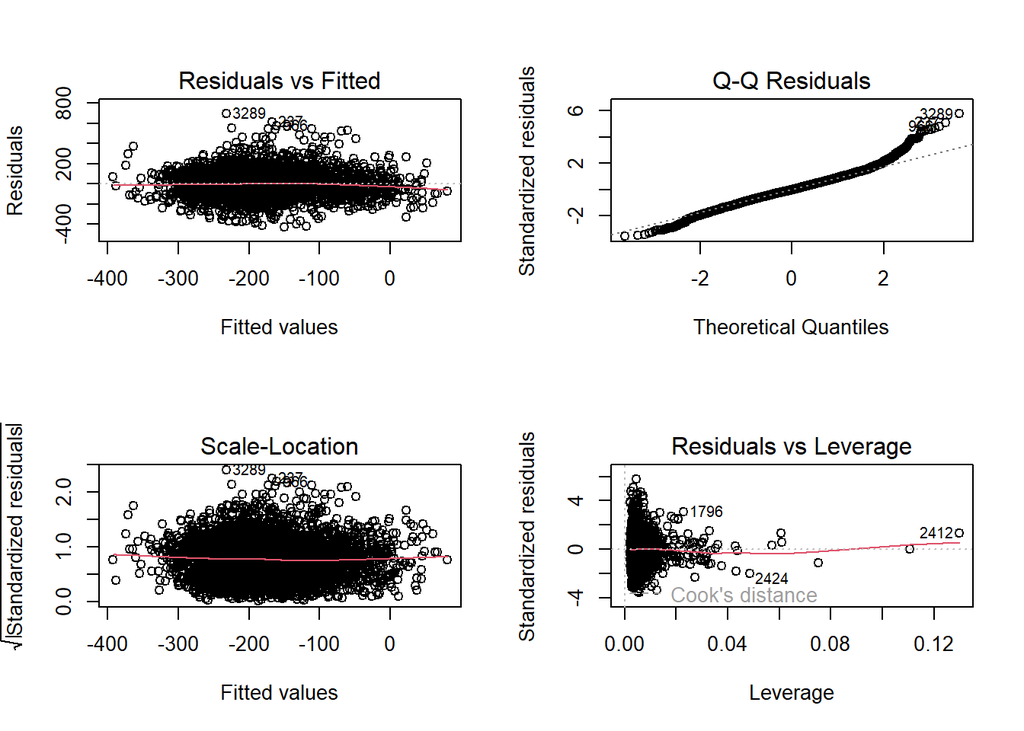

```r
par(mfrow = c(2, 2))
plot(test_spline)
```

Nothing new here.

Let’s test the best spline model with the categorical version of c_breastf.

```r
spline_cat <- lm(zscore ~ ns(c_gender) + ns(c_breastf) + ns(c_age, df = 3) +
    ns(m_agebirth, df = 3) + ns(m_height, df = 3) + ns(m_bmi,
    df = 3) + ns(m_education) + ns(region) + ns(district), data=train_data_cat)
summary(spline_cat)
```

```
##
## Call:
## lm(formula = zscore ~ ns(c_gender) + ns(c_breastf) + ns(c_age,
##     df = 3) + ns(m_agebirth, df = 3) + ns(m_height, df = 3) +
##     ns(m_bmi, df = 3) + ns(m_education) + ns(region) + ns(district),
##     data = train_data_cat)
##
## Residuals:
##     Min      1Q  Median      3Q     Max
## -424.98  -71.61   -3.75   70.15  699.23
##
## Coefficients:
##                         Estimate Std. Error t value Pr(>|t|)
## (Intercept)             -293.509     40.149  -7.311 3.24e-13 ***
## ns(c_gender)             -18.789      4.929  -3.812 0.000140 ***
## ns(c_breastf)             73.534     10.131   7.258 4.74e-13 ***
## ns(c_age, df = 3)1      -197.476     13.721 -14.392  < 2e-16 ***
## ns(c_age, df = 3)2      -407.250     20.344 -20.018  < 2e-16 ***
## ns(c_age, df = 3)3       -96.576      9.524 -10.140  < 2e-16 ***
## ns(m_agebirth, df = 3)1    6.118      9.695   0.631 0.528025
## ns(m_agebirth, df = 3)2   90.540     27.872   3.248 0.001171 **
## ns(m_agebirth, df = 3)3   72.590     17.516   4.144 3.48e-05 ***
## ns(m_height, df = 3)1    148.474     14.330  10.361  < 2e-16 ***
## ns(m_height, df = 3)2    334.810     64.262   5.210 1.99e-07 ***
## ns(m_height, df = 3)3    210.290     37.351   5.630 1.93e-08 ***
## ns(m_bmi, df = 3)1        47.896     13.092   3.659 0.000257 ***
## ns(m_bmi, df = 3)2       121.396     51.520   2.356 0.018509 *
## ns(m_bmi, df = 3)3        78.530     28.137   2.791 0.005282 **
## ns(m_education)           79.655     11.998   6.639 3.62e-11 ***
## ns(region)               -23.966      8.357  -2.868 0.004157 **
## ns(district)              65.354      8.235   7.936 2.73e-15 ***
## ---
## Signif. codes:  0 '***' 0.001 '**' 0.01 '*' 0.05 '.' 0.1 ' ' 1
##
## Residual standard error: 120.8 on 3739 degrees of freedom
## Multiple R-squared:  0.2471, Adjusted R-squared:  0.2437
## F-statistic:  72.2 on 17 and 3739 DF,  p-value: < 2.2e-16
```

Let’s see the test error.

```r
# Test error
predicted <- predict(spline_cat, newdata = test_data_cat)
MSE <- mean((predicted - test_data_cat$zscore)^2)
RMSE <- sqrt(MSE)
MAE <- mean(abs(predicted - test_data_cat$zscore))

paste("MSE: ", MSE, ", RMSE: ", RMSE, ", MAE: ", MAE)
```

```
## [1] "MSE:  15345.0793894607 , RMSE:  123.875257373943 , MAE:  90.7787411303016"
```

```r
AIC <- AIC(spline_cat)
BIC <- BIC(spline_cat)

paste("AIC: ", round(AIC), ", BIC: ", round(BIC))
```

```
## [1] "AIC:  46703 , BIC:  46822"
```

The test error is very close to the previous one, but the AIC and BIC are slightly lower, so we keep this model as the best one.

# Generalized Additive Models

Let’s try to fit a null GAM model.

```r
library(mgcv)
gam_null <- gam(zscore ~ 1, data = train_data)
summary(gam_null)
```

```
##
## Family: gaussian
## Link function: identity
##
## Formula:
## zscore ~ 1
##
## Parametric coefficients:
##             Estimate Std. Error t value Pr(>|t|)
## (Intercept) -172.832      2.266  -76.28   <2e-16 ***
## ---
## Signif. codes:  0 '***' 0.001 '**' 0.01 '*' 0.05 '.' 0.1 ' ' 1
##
##
## R-sq.(adj) =      0   Deviance explained =    0%
## GCV =  19292  Scale est. = 19286     n = 3757
```

```r
# Test error
predicted <- predict(gam_null, newdata = test_data)
MSE <- mean((predicted - test_data$zscore)^2)
RMSE <- sqrt(MSE)
MAE <- mean(abs(predicted - test_data$zscore))

paste("MSE: ", MSE, ", RMSE: ", RMSE, ", MAE: ", MAE)
```

```
## [1] "MSE:  20158.7347897991 , RMSE:  141.98145931705 , MAE:  106.937155462414"
```

```r
AIC <- AIC(gam_null)
BIC <- BIC(gam_null)

paste("AIC: ", round(AIC), ", BIC: ", round(BIC))
```

```
## [1] "AIC:  47736 , BIC:  47748"
```

Let’s try to fit a GAM model with the most correlated variables.

```r
gam_most_correlated <- gam(zscore ~ s(c_breastf) + s(c_age) + s(m_agebirth), data = train_data)
summary(gam_most_correlated)
```

```
##
## Family: gaussian
## Link function: identity
##
## Formula:
## zscore ~ s(c_breastf) + s(c_age) + s(m_agebirth)
##
## Parametric coefficients:
##             Estimate Std. Error t value Pr(>|t|)
## (Intercept)  -172.83       2.09   -82.7   <2e-16 ***
## ---
## Signif. codes:  0 '***' 0.001 '**' 0.01 '*' 0.05 '.' 0.1 ' ' 1
##
## Approximate significance of smooth terms:
##                 edf Ref.df      F p-value
## s(c_breastf)  7.205  8.083 10.454 < 2e-16 ***
## s(c_age)      7.047  8.114 25.884 < 2e-16 ***
## s(m_agebirth) 2.756  3.467  8.624 4.9e-06 ***
## ---
## Signif. codes:  0 '***' 0.001 '**' 0.01 '*' 0.05 '.' 0.1 ' ' 1
##
## R-sq.(adj) =  0.149   Deviance explained = 15.3%
## GCV =  16486  Scale est. = 16407     n = 3757
```

```r
# Test error
predicted <- predict(gam_most_correlated, newdata = test_data)
MSE <- mean((predicted - test_data$zscore)^2)
RMSE <- sqrt(MSE)
MAE <- mean(abs(predicted - test_data$zscore))

paste("MSE: ", MSE, ", RMSE: ", RMSE, ", MAE: ", MAE)
```

```
## [1] "MSE:  17444.87850044 , RMSE:  132.079061551936 , MAE:  99.5955387686355"
```

```r
AIC <- AIC(gam_most_correlated)
BIC <- BIC(gam_most_correlated)

paste("AIC: ", round(AIC), ", BIC: ", round(BIC))
```

```
## [1] "AIC:  47145 , BIC:  47264"
```

Let’s take a look at the residuals.

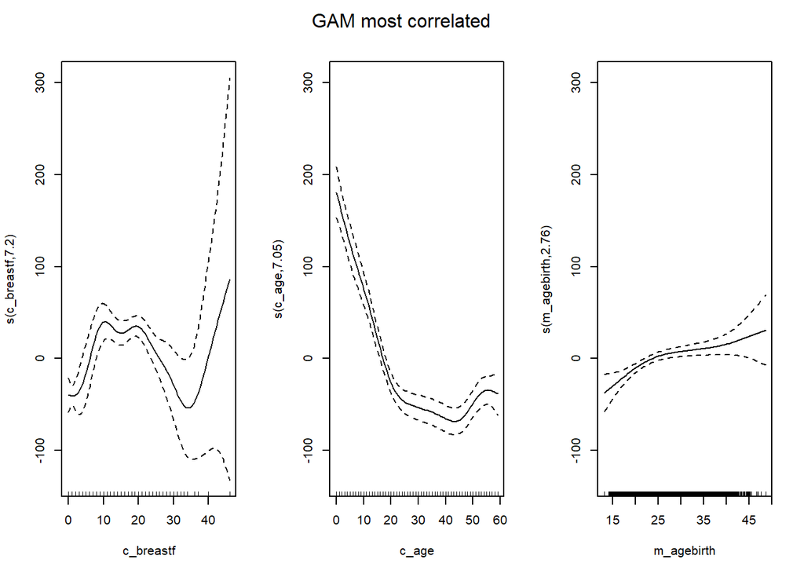

```r
par(mfrow = c(1, 3))
# Without background dots
plot(gam_most_correlated, pch = 20, cex = 0.5)
mtext("GAM most correlated", side = 3, line = -2, outer = TRUE)
```

```r
par(mfrow = c(1, 1))
```

*how can we interpret the residual plots?*

Let’s try to fit a GAM model with all the variables.

```r
gam_full <- gam(zscore ~ c_gender + s(c_breastf) + s(c_age) + s(m_agebirth) + s(m_height) + s(m_bmi) + m_education + m_work + region + district, data = train_data)
summary(gam_full)
```

```
##
## Family: gaussian
## Link function: identity
##
## Formula:
## zscore ~ c_gender + s(c_breastf) + s(c_age) + s(m_agebirth) +
##     s(m_height) + s(m_bmi) + m_education + m_work + region +
##     district
##
## Parametric coefficients:
##               Estimate Std. Error t value Pr(>|t|)
## (Intercept)  -167.0335     5.8957 -28.331  < 2e-16 ***
## c_gender1     -14.3227     3.9550  -3.621 0.000297 ***
## m_education2   10.1940     5.6874   1.792 0.073153 .
## m_education3   26.7966     7.5157   3.565 0.000368 ***
## m_education4   86.1054    16.2999   5.283 1.35e-07 ***
## m_work1        -2.0933     4.3143  -0.485 0.627564
## region2         1.1690     5.3289   0.219 0.826380
## region3       -25.1856     6.8626  -3.670 0.000246 ***
## region4       -34.3930     6.2928  -5.465 4.92e-08 ***
## region5        10.8026     4.7624   2.268 0.023368 *
## region6       -47.9738    13.6516  -3.514 0.000446 ***
## region7       -25.7320     7.6785  -3.351 0.000813 ***
## region8         1.4518     6.2901   0.231 0.817480
## region9        -9.0599     7.3322  -1.236 0.216674
## district13    -14.1265    12.2110  -1.157 0.247401
## district14     33.4040    21.7426   1.536 0.124542
## district15     10.2994    15.0434   0.685 0.493610
## district21    -79.6948    32.4755  -2.454 0.014174 *
## district22     24.8367    19.1403   1.298 0.194501
## district23     40.1162    22.9550   1.748 0.080617 .
## district24    -31.3806    18.3253  -1.712 0.086905 .
## district25    -34.4931    21.1509  -1.631 0.103015
## district26     -4.3966    22.2325  -0.198 0.843247
## district27     -1.6302    13.5228  -0.121 0.904050
## district28    -14.4389    25.4287  -0.568 0.570193
## district31      2.4449    11.4246   0.214 0.830554
## district32     -8.9511    18.3213  -0.489 0.625179
## district33    -31.8837    37.5074  -0.850 0.395345
## district34     14.1779    16.2028   0.875 0.381615
```

[output cut: 39 more lines]

```
## Signif. codes:  0 '***' 0.001 '**' 0.01 '*' 0.05 '.' 0.1 ' ' 1
##
## Approximate significance of smooth terms:
##                 edf Ref.df       F  p-value
## s(c_breastf)  3.161  3.940  12.022  < 2e-16 ***
## s(c_age)      4.648  5.719  67.858  < 2e-16 ***
## s(m_agebirth) 2.702  3.408   4.916  0.00146 **
## s(m_height)   1.480  1.841 106.793  < 2e-16 ***
## s(m_bmi)      1.026  1.051  17.866 1.77e-05 ***
## ---
## Signif. codes:  0 '***' 0.001 '**' 0.01 '*' 0.05 '.' 0.1 ' ' 1
##
## Rank: 104/112
## R-sq.(adj) =  0.254   Deviance explained = 26.8%
## GCV =  14663  Scale est. = 14382     n = 3757
```

```r
# Test error
predicted <- predict(gam_full, newdata = test_data)
MSE <- mean((predicted - test_data$zscore)^2)
RMSE <- sqrt(MSE)
MAE <- mean(abs(predicted - test_data$zscore))

paste("MSE: ", MSE, ", RMSE: ", RMSE, ", MAE: ", MAE)
```

```
## [1] "MSE:  15023.3638544195 , RMSE:  122.569832562582 , MAE:  89.8210292028362"
```

```r
AIC <- AIC(gam_full)
BIC <- BIC(gam_full)

paste("AIC: ", round(AIC), ", BIC: ", round(BIC))
```

```
## [1] "AIC:  46704 , BIC:  47159"
```

The full GAM model performs better than the all the previous ones on the test set.

Let’s plot the residuals.

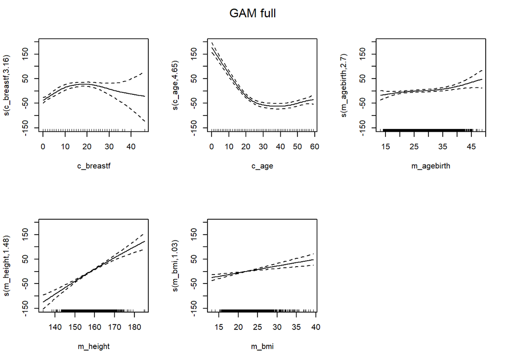

```r
par(mfrow = c(2, 3))
plot(gam_full, pch = 20, cex = 0.5)
mtext("GAM full", side = 3, line = -2, outer = TRUE)
par(mfrow = c(1, 1))
```

```r
anova(gam_null, gam_most_correlated, gam_full)
```

```
## Analysis of Deviance Table
##
## Model 1: zscore ~ 1
## Model 2: zscore ~ s(c_breastf) + s(c_age) + s(m_agebirth)
## Model 3: zscore ~ c_gender + s(c_breastf) + s(c_age) + s(m_agebirth) +
##     s(m_height) + s(m_bmi) + m_education + m_work + region +
##     district
##   Resid. Df Resid. Dev     Df Deviance
## 1    3756.0   72440010
## 2    3736.3   61346026 19.664 11093984
## 3    3682.0   52998568 54.295  8347458
```

Using more variables seems to be the best choice, the model with more predictors has also lower AIC, BIC and test errors.

Let’s try to remove the less significant predictors.

```r
gam_most_significant <- gam(zscore ~ c_gender + s(c_breastf) + s(c_age) + s(m_agebirth) + s(m_height) + s(m_bmi) + m_education + region, data = train_data)
summary(gam_most_significant)
```

```
##
## Family: gaussian
## Link function: identity
##
## Formula:
## zscore ~ c_gender + s(c_breastf) + s(c_age) + s(m_agebirth) +
##     s(m_height) + s(m_bmi) + m_education + region
##
## Parametric coefficients:
##              Estimate Std. Error t value Pr(>|t|)
## (Intercept)  -174.283      8.295 -21.011  < 2e-16 ***
## c_gender1     -14.137      3.947  -3.582 0.000346 ***
## m_education2    9.720      5.465   1.779 0.075392 .
## m_education3   29.523      7.174   4.115 3.95e-05 ***
## m_education4   84.808     15.981   5.307 1.18e-07 ***
## region2        11.353      7.952   1.428 0.153453
## region3       -21.891      9.518  -2.300 0.021505 *
## region4       -33.025      9.518  -3.470 0.000527 ***
## region5        14.138      8.608   1.642 0.100578
## region6       -38.426      9.213  -4.171 3.10e-05 ***
## region7       -17.283     10.774  -1.604 0.108772
## region8         9.609      8.449   1.137 0.255501
## region9        -3.314     10.376  -0.319 0.749480
## ---
## Signif. codes:  0 '***' 0.001 '**' 0.01 '*' 0.05 '.' 0.1 ' ' 1
##
## Approximate significance of smooth terms:
##                 edf Ref.df       F  p-value
## s(c_breastf)  3.196  3.978  12.315  < 2e-16 ***
## s(c_age)      4.421  5.456  70.869  < 2e-16 ***
## s(m_agebirth) 2.485  3.136   5.187  0.00126 **
## s(m_height)   1.555  1.954 102.726  < 2e-16 ***
## s(m_bmi)      1.141  1.270  14.959 2.82e-05 ***
## ---
## Signif. codes:  0 '***' 0.001 '**' 0.01 '*' 0.05 '.' 0.1 ' ' 1
##
## R-sq.(adj) =  0.247   Deviance explained = 25.2%
## GCV =  14616  Scale est. = 14516     n = 3757
```

```r
# Test error

predicted <- predict(gam_most_significant, newdata = test_data)
MSE <- mean((predicted - test_data$zscore)^2)
RMSE <- sqrt(MSE)
MAE <- mean(abs(predicted - test_data$zscore))

paste("MSE: ", MSE, ", RMSE: ", RMSE, ", MAE: ", MAE)
```

```
## [1] "MSE:  15186.430729153 , RMSE:  123.233237112205 , MAE:  89.924288602152"
```

```r
AIC <- AIC(gam_most_significant)
BIC <- BIC(gam_most_significant)

paste("AIC: ", round(AIC), ", BIC: ", round(BIC))
```

```
## [1] "AIC:  46693 , BIC:  46860"
```

The model with the most significant predictors has a lower BIC and AIC than the other GAMs, it performs quite similarly as the full GAM model on the test set and, but it has a slightly lower deviance explained. The model has improved.

Let’s try to fit a GAM model with interaction between c_age and c_breastf.

```r
gam_interaction <- gam(zscore ~ c_gender + s(c_breastf) + s(c_age) + s(m_agebirth) + s(m_height) + s(m_bmi) + m_education + region + te(c_breastf, c_age), data = train_data)
summary(gam_interaction)
```

```
##
## Family: gaussian
## Link function: identity
##
## Formula:
## zscore ~ c_gender + s(c_breastf) + s(c_age) + s(m_agebirth) +
##     s(m_height) + s(m_bmi) + m_education + region + te(c_breastf,
##     c_age)
##
## Parametric coefficients:
##              Estimate Std. Error t value Pr(>|t|)
## (Intercept)  -174.366      8.295 -21.020  < 2e-16 ***
## c_gender1     -14.130      3.947  -3.580 0.000348 ***
## m_education2    9.868      5.464   1.806 0.070976 .
## m_education3   29.709      7.174   4.141 3.53e-05 ***
## m_education4   84.548     15.984   5.289 1.30e-07 ***
## region2        11.399      7.952   1.434 0.151789
## region3       -22.395      9.509  -2.355 0.018571 *
## region4       -32.798      9.520  -3.445 0.000577 ***
## region5        14.140      8.607   1.643 0.100494
## region6       -38.245      9.217  -4.149 3.41e-05 ***
## region7       -17.424     10.771  -1.618 0.105797
## region8         9.642      8.449   1.141 0.253857
## region9        -3.912     10.365  -0.377 0.705913
## ---
## Signif. codes:  0 '***' 0.001 '**' 0.01 '*' 0.05 '.' 0.1 ' ' 1
##
## Approximate significance of smooth terms:
##                       edf Ref.df       F p-value
## s(c_breastf)        2.574  3.304  14.051 < 2e-16 ***
## s(c_age)            4.627  5.735  46.073 < 2e-16 ***
## s(m_agebirth)       2.458  3.103   5.122 0.00142 **
## s(m_height)         1.530  1.917 104.163 < 2e-16 ***
## s(m_bmi)            1.093  1.180  16.416 1.9e-05 ***
## te(c_breastf,c_age) 1.000  1.000   1.185 0.27647
## ---
## Signif. codes:  0 '***' 0.001 '**' 0.01 '*' 0.05 '.' 0.1 ' ' 1
##
## R-sq.(adj) =  0.247   Deviance explained = 25.2%
## GCV =  14619  Scale est. = 14517     n = 3757
```

```r
# Test error
predicted <- predict(gam_interaction, newdata = test_data)
MSE <- mean((predicted - test_data$zscore)^2)
RMSE <- sqrt(MSE)
MAE <- mean(abs(predicted - test_data$zscore))

paste("MSE: ", MSE, ", RMSE: ", RMSE, ", MAE: ", MAE)
```

```
## [1] "MSE:  15141.1931965023 , RMSE:  123.049555856583 , MAE:  89.8128554325454"
```

```r
AIC <- AIC(gam_interaction)
BIC <- BIC(gam_interaction)

paste("AIC: ", round(AIC), ", BIC: ", round(BIC))
```

```
## [1] "AIC:  46694 , BIC:  46864"
```

Here the interaction term is not significant, AIC and BIC are higher but the test error is similar to the previous model. No need to include the interaction term.

Let’s now test the categorical version of c_breastf.

```r
gam_c_breastf_cat <- gam(zscore ~ c_gender + c_breastf + s(c_age) + s(m_agebirth) + s(m_height) + s(m_bmi) + m_education + region, data = train_data_cat)
summary(gam_c_breastf_cat)
```

```
##
## Family: gaussian
## Link function: identity
##
## Formula:
## zscore ~ c_gender + c_breastf + s(c_age) + s(m_agebirth) + s(m_height) +
##     s(m_bmi) + m_education + region
##
## Parametric coefficients:
##              Estimate Std. Error t value Pr(>|t|)
## (Intercept)  -210.272      9.742 -21.585  < 2e-16 ***
## c_gender1     -14.188      3.947  -3.595 0.000329 ***
## c_breastf1     60.039      8.345   7.194 7.54e-13 ***
## m_education2   10.778      5.454   1.976 0.048205 *
## m_education3   29.956      7.170   4.178 3.01e-05 ***
## m_education4   85.248     15.963   5.340 9.82e-08 ***
## region2        11.222      7.951   1.411 0.158209
## region3       -23.528      9.409  -2.501 0.012440 *
## region4       -32.714      9.519  -3.437 0.000595 ***
## region5        13.357      8.598   1.554 0.120359
## region6       -38.467      9.190  -4.186 2.91e-05 ***
## region7       -17.844     10.755  -1.659 0.097181 .
## region8         9.607      8.423   1.141 0.254116
## region9        -6.023     10.246  -0.588 0.556680
## ---
## Signif. codes:  0 '***' 0.001 '**' 0.01 '*' 0.05 '.' 0.1 ' ' 1
##
## Approximate significance of smooth terms:
##                 edf Ref.df       F  p-value
## s(c_age)      4.008  4.974  91.868  < 2e-16 ***
## s(m_agebirth) 2.512  3.170   4.792  0.00215 **
## s(m_height)   1.542  1.935 104.235  < 2e-16 ***
## s(m_bmi)      1.000  1.000  20.292 7.15e-06 ***
## ---
## Signif. codes:  0 '***' 0.001 '**' 0.01 '*' 0.05 '.' 0.1 ' ' 1
##
## R-sq.(adj) =  0.247   Deviance explained = 25.1%
## GCV =  14611  Scale est. = 14522     n = 3757
```

```r
# Test error
predicted <- predict(gam_c_breastf_cat, newdata = test_data_cat)
MSE <- mean((predicted - test_data_cat$zscore)^2)
RMSE <- sqrt(MSE)
MAE <- mean(abs(predicted - test_data_cat$zscore))

paste("MSE: ", MSE, ", RMSE: ", RMSE, ", MAE: ", MAE)
```

```
## [1] "MSE:  15213.273679352 , RMSE:  123.342100190292 , MAE:  89.9739460315468"
```

```r
AIC <- AIC(gam_c_breastf_cat)
BIC <- BIC(gam_c_breastf_cat)

paste("AIC: ", round(AIC), ", BIC: ", round(BIC))
```

```
## [1] "AIC:  46692 , BIC:  46842"
```

Here the model is pretty much the same as the one with the continuous version of c_breastf. The test error is slightly higher, but the AIC and BIC are lower. We can keep the continuous version of c_breastf as the best model.

Since in every gam the m_height and m_bmi predictors have low edf for the significance of smooth terms, we can try to make them linear.

```r
gam_linear_height_bmi <- gam(zscore ~ c_gender + s(c_breastf) + s(c_age) + s(m_agebirth) + m_height + m_bmi + m_education + region, data = train_data)
summary(gam_linear_height_bmi)
```

```
##
## Family: gaussian
## Link function: identity
##
## Formula:
## zscore ~ c_gender + s(c_breastf) + s(c_age) + s(m_agebirth) +
##     m_height + m_bmi + m_education + region
##
## Parametric coefficients:
##                Estimate Std. Error t value Pr(>|t|)
## (Intercept)  -1002.5544    56.6840 -17.687  < 2e-16 ***
## c_gender1      -14.0774     3.9467  -3.567 0.000366 ***
## m_height         4.8476     0.3404  14.239  < 2e-16 ***
## m_bmi            2.8367     0.6306   4.499 7.05e-06 ***
## m_education2     9.8329     5.4634   1.800 0.071978 .
## m_education3    29.6769     7.1727   4.137 3.59e-05 ***
## m_education4    85.1022    15.9798   5.326 1.07e-07 ***
## region2         11.2394     7.9510   1.414 0.157570
## region3        -22.0110     9.5176  -2.313 0.020796 *
## region4        -33.2708     9.5159  -3.496 0.000477 ***
## region5         13.9955     8.6064   1.626 0.103996
## region6        -38.4468     9.2140  -4.173 3.08e-05 ***
## region7        -17.4381    10.7735  -1.619 0.105617
## region8          9.5883     8.4497   1.135 0.256556
## region9         -3.2850    10.3743  -0.317 0.751525
## ---
## Signif. codes:  0 '***' 0.001 '**' 0.01 '*' 0.05 '.' 0.1 ' ' 1
##
## Approximate significance of smooth terms:
##                 edf Ref.df      F p-value
## s(c_breastf)  3.150  3.924 12.369 < 2e-16 ***
## s(c_age)      4.420  5.455 71.134 < 2e-16 ***
## s(m_agebirth) 2.472  3.121  5.164 0.00131 **
## ---
## Signif. codes:  0 '***' 0.001 '**' 0.01 '*' 0.05 '.' 0.1 ' ' 1
##
## R-sq.(adj) =  0.247   Deviance explained = 25.2%
## GCV =  14617  Scale est. = 14520     n = 3757
```

```r
# Test error
predicted <- predict(gam_linear_height_bmi, newdata = test_data)
MSE <- mean((predicted - test_data$zscore)^2)
RMSE <- sqrt(MSE)
MAE <- mean(abs(predicted - test_data$zscore))

paste("MSE: ", MSE, ", RMSE: ", RMSE, ", MAE: ", MAE)
```

```
## [1] "MSE:  15189.8507842785 , RMSE:  123.247112681306 , MAE:  89.9186388071975"
```

```r
AIC <- AIC(gam_linear_height_bmi)
BIC <- BIC(gam_linear_height_bmi)

paste("AIC: ", round(AIC), ", BIC: ", round(BIC))
```

```
## [1] "AIC:  46693 , BIC:  46856"
```

Not much different from the previous model.

Let’s analyze the residual plots.

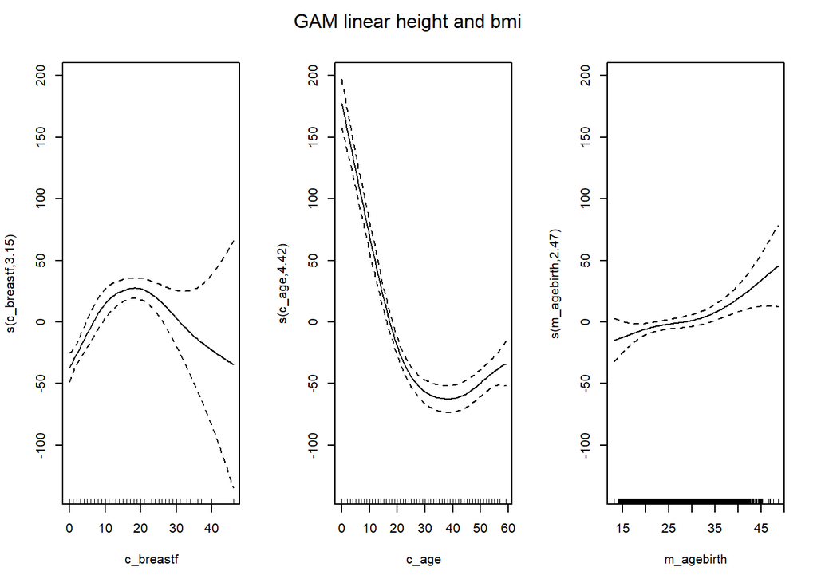

```r
par(mfrow = c(1, 3))
plot(gam_linear_height_bmi, pch = 20, cex = 0.5)
mtext("GAM linear height and bmi", side = 3, line = -2, outer = TRUE)
```

```r
par(mfrow = c(1, 1))
```

Let’s perform an ANOVA test.

```r
anova(gam_null, gam_most_significant, gam_linear_height_bmi, test = "F")
```

```
## Analysis of Deviance Table
##
## Model 1: zscore ~ 1
## Model 2: zscore ~ c_gender + s(c_breastf) + s(c_age) + s(m_agebirth) +
##     s(m_height) + s(m_bmi) + m_education + region
## Model 3: zscore ~ c_gender + s(c_breastf) + s(c_age) + s(m_agebirth) +
##     m_height + m_bmi + m_education + region
##   Resid. Df Resid. Dev      Df Deviance       F Pr(>F)
## 1    3756.0   72440010
## 2    3728.2   54160573 27.7955 18279436 45.3059 <2e-16 ***
## 3    3729.5   54187615 -1.2953   -27041  1.4382  0.236
## ---
## Signif. codes:  0 '***' 0.001 '**' 0.01 '*' 0.05 '.' 0.1 ' ' 1
```

The linearization of predictors does not result in a statistically significant change in deviance, so we will keep the GAM without the least significant predictors as the best GAM.

# MARS

```r
library(earth)
mars_full <- earth(zscore ~ ., data = train_data)
summary(mars_full)
```

```
## Call: earth(formula=zscore~., data=train_data)
##
##                       coefficients
## (Intercept)               0.586104
## c_gender1               -14.119541
## m_education3             21.824613
## m_education4             79.023786
## region3                 -31.876011
## region4                 -41.455683
## region6                 -35.894178
## region7                 -26.051344
## district21              -91.736333
## district25              -52.003358
## district36              -52.132719
## district89               27.553742
## h(15-c_breastf)          -4.930548
## h(c_breastf-15)          -1.887234
## h(17-c_age)              10.511581
## h(c_age-17)              -7.466524
## h(c_age-23)               5.635521
## h(c_age-35)               3.003204
## h(41.6667-m_agebirth)    -0.762505
## h(m_agebirth-41.6667)    13.998881
## h(171-m_height)          -4.972565
## h(36.83-m_bmi)           -3.171743
##
## Selected 22 of 24 terms, and 16 of 71 predictors
## Termination condition: RSq changed by less than 0.001 at 24 terms
## Importance: c_age, m_height, m_bmi, region6, c_breastf, m_education4, ...
## Number of terms at each degree of interaction: 1 21 (additive model)
## GCV 14645.06    RSS 53769221    GRSq 0.2408587    RSq 0.2577414
```

```r
# Test error
predicted <- predict(mars_full, newdata = test_data)
MSE <- mean((predicted - test_data$zscore)^2)
RMSE <- sqrt(MSE)
MAE <- mean(abs(predicted - test_data$zscore))

paste("MSE: ", MSE, ", RMSE: ", RMSE, ", MAE: ", MAE)
```

```
## [1] "MSE:  15080.3602761553 , RMSE:  122.802118369983 , MAE:  89.6420999160898"
```

Let’s plot the residuals.

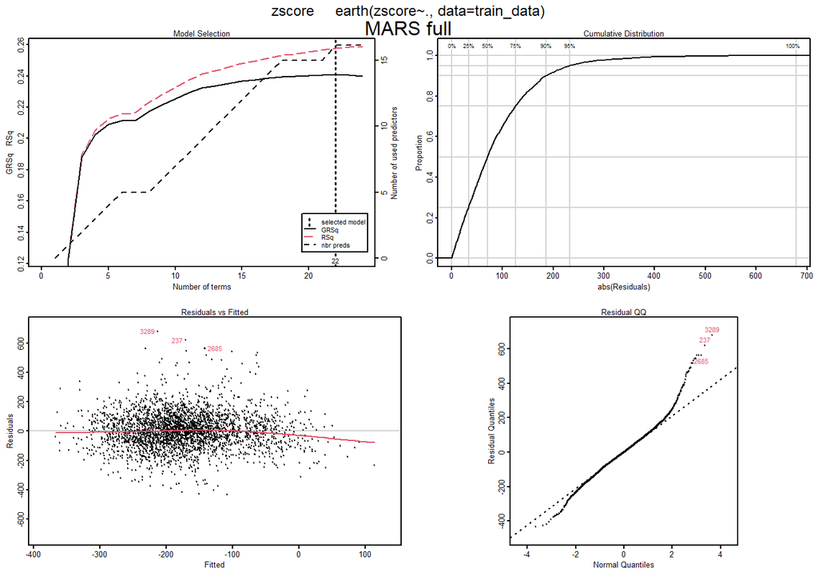

```r
par(mfrow = c(2, 2))
plot(mars_full, residuals = TRUE, pch = 20, cex = 0.5)
mtext("MARS full", side = 3, line = -2, outer = TRUE)
```

```r
par(mfrow = c(1, 1))
```

*??*

Let’s try the categorical version of c_breastf.

```r
mars_c_breastf_cat <- earth(zscore ~ ., data = train_data_cat)
summary(mars_c_breastf_cat)
```

```
## Call: earth(formula=zscore~., data=train_data_cat)
##
##                       coefficients
## (Intercept)             -68.986629
## c_gender1               -14.144508
## c_breastf1               65.101218
## m_education3             21.471630
## m_education4             78.906223
## region3                 -33.623464
## region4                 -40.583054
## region6                 -35.331883
## region7                 -26.406051
## district21              -95.245710
## district25              -53.531057
## district36              -51.030698
## district89               27.869878
## h(17-c_age)              10.173719
## h(c_age-17)              -7.944842
## h(c_age-23)               5.850714
## h(c_age-35)               3.243249
## h(41.8333-m_agebirth)    -0.702402
## h(m_agebirth-41.8333)    14.814802
## h(171-m_height)          -4.998762
## h(36.83-m_bmi)           -3.204362
##
## Selected 21 of 23 terms, and 16 of 71 predictors
## Termination condition: RSq changed by less than 0.001 at 23 terms
## Importance: c_age, m_height, m_bmi, c_breastf1, region6, m_education4, ...
## Number of terms at each degree of interaction: 1 20 (additive model)
## GCV 14630    RSS 53771802    GRSq 0.2416392    RSq 0.2577058
```

```r
# Test error
predicted <- predict(mars_c_breastf_cat, newdata = test_data_cat)
MSE <- mean((predicted - test_data_cat$zscore)^2)
RMSE <- sqrt(MSE)
MAE <- mean(abs(predicted - test_data_cat$zscore))

paste("MSE: ", MSE, ", RMSE: ", RMSE, ", MAE: ", MAE)
```

```
## [1] "MSE:  15092.2020207562 , RMSE:  122.850323649375 , MAE:  89.5832442284726"
```

# Trees

Let’s try to fit a regression tree with the most correlated predictors.

```r
library(rpart)

tree_most_correlated <- rpart(zscore ~ c_breastf + c_age + m_agebirth, data = train_data)
summary(tree_most_correlated)
```

```
## Call:
## rpart(formula = zscore ~ c_breastf + c_age + m_agebirth, data = train_data)
##   n= 3757
##
##          CP nsplit rel error    xerror       xstd
## 1 0.1102669      0 1.0000000 1.0005737 0.02950126
## 2 0.0100000      1 0.8897331 0.8966996 0.02706864
##
## Variable importance
##     c_age c_breastf
##        52        48
##
## Node number 1: 3757 observations,    complexity param=0.1102669
##   mean=-172.8318, MSE=19281.34
##   left son=2 (2924 obs) right son=3 (833 obs)
##   Primary splits:
##       c_age      < 10.5     to the right, improve=0.110266900, (0 missing)
##       c_breastf  < 0.5      to the right, improve=0.107301000, (0 missing)
##       m_agebirth < 20.04167 to the left,  improve=0.005308141, (0 missing)
##   Surrogate splits:
##       c_breastf  < 0.5      to the right, agree=0.980, adj=0.908, (0 split)
##       m_agebirth < 47.33334 to the left,  agree=0.779, adj=0.001, (0 split)
##
## Node number 2: 2924 observations
##   mean=-197.4425, MSE=17398.04
##
## Node number 3: 833 observations
##   mean=-86.44298, MSE=16303.01
```

```r
# Test error
predicted <- predict(tree_most_correlated, newdata = test_data)
MSE <- mean((predicted - test_data$zscore)^2)
RMSE <- sqrt(MSE)
MAE <- mean(abs(predicted - test_data$zscore))

paste("MSE: ", MSE, ", RMSE: ", RMSE, ", MAE: ", MAE)
```

```
## [1] "MSE:  18535.6255709647 , RMSE:  136.145604302764 , MAE:  101.123569237165"
```

Let’s plot the tree.

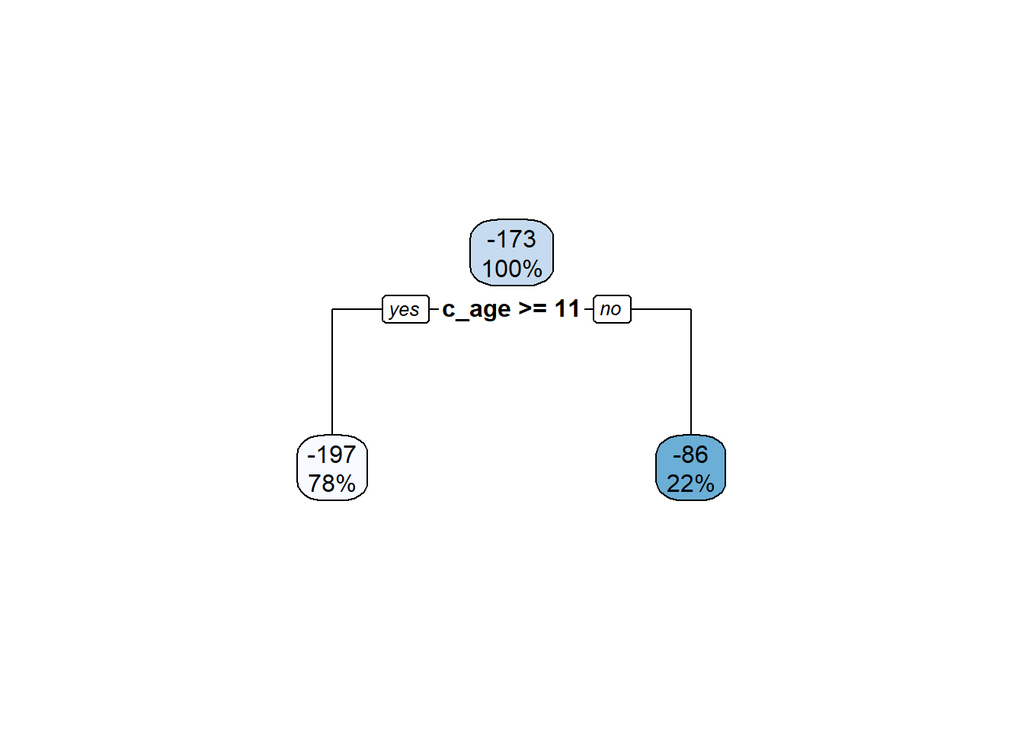

```r
library(rpart.plot)

rpart.plot(tree_most_correlated)
```

It appears that only the c_age variable is used to split the data.

Let’s try to fit a regression tree with all the variables.

```r
tree_full <- rpart(zscore ~ ., data = train_data)
summary(tree_full)
```

```
## Call:
## rpart(formula = zscore ~ ., data = train_data)
##   n= 3757
##
##           CP nsplit rel error    xerror       xstd
## 1 0.11026692      0 1.0000000 1.0006694 0.02949988
## 2 0.04920590      1 0.8897331 0.8977609 0.02707111
## 3 0.01586682      2 0.8405272 0.8654881 0.02645233
## 4 0.01574749      3 0.8246604 0.8572296 0.02626241
## 5 0.01546066      4 0.8089129 0.8543203 0.02630083
## 6 0.01000000      5 0.7934522 0.8376423 0.02605969
##
## Variable importance
##     c_age c_breastf  district    region  m_height
##        31        28        19        11        10
##
## Node number 1: 3757 observations,    complexity param=0.1102669
##   mean=-172.8318, MSE=19281.34
##   left son=2 (2924 obs) right son=3 (833 obs)
##   Primary splits:
##       c_age     < 10.5     to the right, improve=0.11026690, (0 missing)
##       c_breastf < 0.5      to the right, improve=0.10730100, (0 missing)
##       district  splits as  LLLLLLLLLLLLLLLRLLRRRRLLRRLLRRLLLLLLLRRRLLRRRRRRRLRRRL, improve=0.05378244, (0 missing)
##       m_height  < 157.45   to the left,  improve=0.04624426, (0 missing)
##       region    splits as  RRLLRLLRR, improve=0.04144502, (0 missing)
##   Surrogate splits:
##       c_breastf  < 0.5      to the right, agree=0.980, adj=0.908, (0 split)
##       m_agebirth < 47.33334 to the left,  agree=0.779, adj=0.001, (0 split)
##
## Node number 2: 2924 observations,    complexity param=0.0492059
##   mean=-197.4425, MSE=17398.04
##   left son=4 (985 obs) right son=5 (1939 obs)
##   Primary splits:
##       district    splits as  LLLLLLRLLLLLLLLRLLRRRRLLRRLLRRRLLLLLRRRRLRRRRRRRRRRRRL, improve=0.07006772, (0 missing)
##       m_height    < 157.25   to the left,  improve=0.06498373, (0 missing)
##       region      splits as  RRLLRLLRR, improve=0.05783817, (0 missing)
##       m_education splits as  LLRR, improve=0.02754898, (0 missing)
##       m_bmi       < 24.095   to the left,  improve=0.01810525, (0 missing)
##   Surrogate splits:
##       region     splits as  RRLLRLLRR,    agree=0.868, adj=0.607, (0 split)
```

[output cut: 51 more lines]

```
##
## Node number 7: 529 observations
##   mean=-58.6465, MSE=16395.8
##
## Node number 8: 603 observations
##   mean=-273.5158, MSE=15552.69
##
## Node number 9: 382 observations
##   mean=-203.6728, MSE=18716.7
##
## Node number 10: 742 observations
##   mean=-203.4811, MSE=14322.41
##
## Node number 11: 1197 observations
##   mean=-153.3885, MSE=14922.28
```

```r
# Test error
predicted <- predict(tree_full, newdata = test_data)
MSE <- mean((predicted - test_data$zscore)^2)
RMSE <- sqrt(MSE)
MAE <- mean(abs(predicted - test_data$zscore))

paste("MSE: ", MSE, ", RMSE: ", RMSE, ", MAE: ", MAE)
```

```
## [1] "MSE:  17246.9493540707 , RMSE:  131.327641241555 , MAE:  96.1226290081121"
```

Let’s plot the tree.

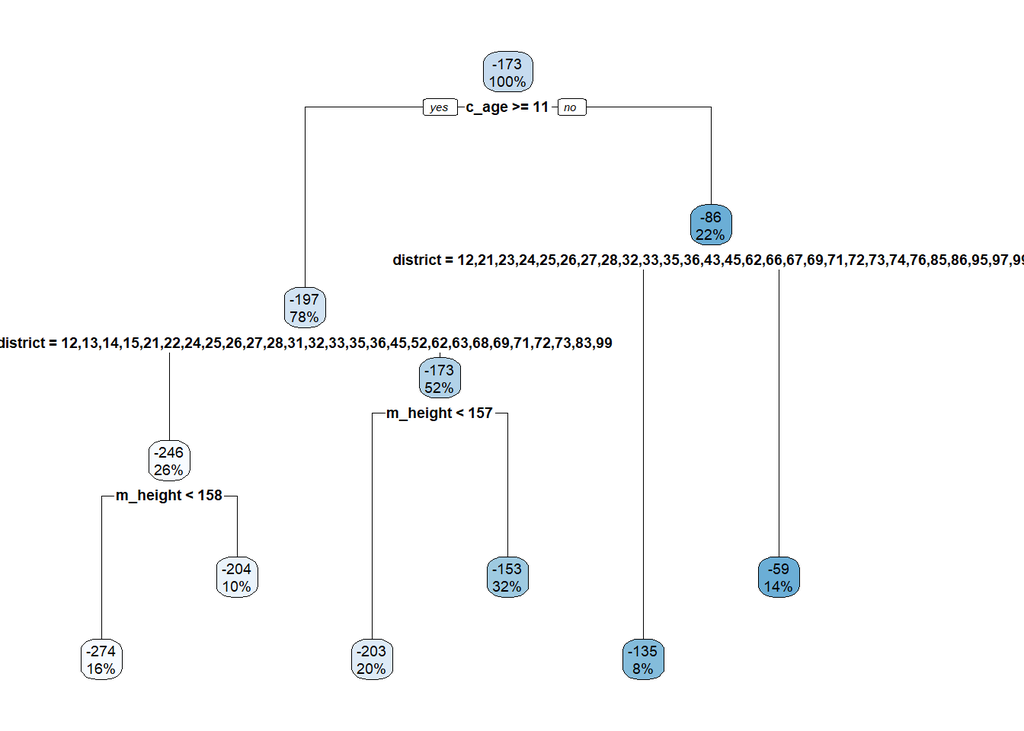

```r
rpart.plot(tree_full)
```

# Random Forest

Let’s try to fit a random forest model with the most correlated predictors.

```r
library(randomForest)
X <- train_data[, c("c_breastf", "c_age", "m_agebirth")]
X_test <- test_data[, c("c_breastf", "c_age", "m_agebirth")]
y <- train_data$zscore
y_test <- test_data$zscore

set.seed(123)

random_forest_most_correlated <- randomForest(zscore ~ c_breastf + c_age + m_agebirth, data = train_data, ntree = 1000, mtry = 2, importance = TRUE)
summary(random_forest_most_correlated)
```

```
##                 Length Class  Mode
## call               6   -none- call
## type               1   -none- character
## predicted       3757   -none- numeric
## mse             1000   -none- numeric
## rsq             1000   -none- numeric
## oob.times       3757   -none- numeric
## importance         6   -none- numeric
## importanceSD       3   -none- numeric
## localImportance    0   -none- NULL
## proximity          0   -none- NULL
## ntree              1   -none- numeric
## mtry               1   -none- numeric
## forest            11   -none- list
## coefs              0   -none- NULL
## y               3757   -none- numeric
## test               0   -none- NULL
## inbag              0   -none- NULL
## terms              3   terms  call
```

```r
# Test error
predicted <- predict(random_forest_most_correlated, newdata = test_data)
MSE <- mean((predicted - test_data$zscore)^2)
RMSE <- sqrt(MSE)
MAE <- mean(abs(predicted - test_data$zscore))

paste("MSE: ", MSE, ", RMSE: ", RMSE, ", MAE: ", MAE)
```

```
## [1] "MSE:  18527.8750213287 , RMSE:  136.117137133164 , MAE:  104.713664021173"
```

Let’s try to fit a random forest model with all the variables.

```r
random_forest_full <- randomForest(zscore ~ . - district, data = train_data, ntree = 1000, importance = TRUE) # District has too many levels and can't be used
summary(random_forest_full)
```

```
##                 Length Class  Mode
## call               5   -none- call
## type               1   -none- character
## predicted       3757   -none- numeric
## mse             1000   -none- numeric
## rsq             1000   -none- numeric
## oob.times       3757   -none- numeric
## importance        18   -none- numeric
## importanceSD       9   -none- numeric
## localImportance    0   -none- NULL
## proximity          0   -none- NULL
## ntree              1   -none- numeric
## mtry               1   -none- numeric
## forest            11   -none- list
## coefs              0   -none- NULL
## y               3757   -none- numeric
## test               0   -none- NULL
## inbag              0   -none- NULL
## terms              3   terms  call
```

```r
# Test error
predicted <- predict(random_forest_full, newdata = test_data)
MSE <- mean((predicted - test_data$zscore)^2)
RMSE <- sqrt(MSE)
MAE <- mean(abs(predicted - test_data$zscore))

paste("MSE: ", MSE, ", RMSE: ", RMSE, ", MAE: ", MAE)
```

```
## [1] "MSE:  15125.9275356572 , RMSE:  122.98750967337 , MAE:  90.996190841767"
```

```r
# Variable importance
importance(random_forest_full)
```

```
##               %IncMSE IncNodePurity
## c_gender     1.517437       1315008
## c_breastf   43.446583       8117021
## c_age       51.587848      12447766
## m_agebirth  10.323403       9461405
## m_height    54.055183      12995475
## m_bmi       18.535220       9853388
## m_education 21.686042       2653579
## m_work       5.891907       1208518
## region      36.027418       7452694
```

Let’s drop the variables that have a low node purity.

```r
random_forest_full_drop <- randomForest(zscore ~ . - district - c_gender - m_education - m_work - region, data = train_data, ntree = 1000, importance = TRUE)
summary(random_forest_full_drop)
```

```
##                 Length Class  Mode
## call               5   -none- call
## type               1   -none- character
## predicted       3757   -none- numeric
## mse             1000   -none- numeric
## rsq             1000   -none- numeric
## oob.times       3757   -none- numeric
## importance        10   -none- numeric
## importanceSD       5   -none- numeric
## localImportance    0   -none- NULL
## proximity          0   -none- NULL
## ntree              1   -none- numeric
## mtry               1   -none- numeric
## forest            11   -none- list
## coefs              0   -none- NULL
## y               3757   -none- numeric
## test               0   -none- NULL
## inbag              0   -none- NULL
## terms              3   terms  call
```

```r
# Test error
predicted <- predict(random_forest_full_drop, newdata = test_data)
MSE <- mean((predicted - test_data$zscore)^2)
RMSE <- sqrt(MSE)
MAE <- mean(abs(predicted - test_data$zscore))

paste("MSE: ", MSE, ", RMSE: ", RMSE, ", MAE: ", MAE)
```

```
## [1] "MSE:  15854.7595731897 , RMSE:  125.915684381215 , MAE:  95.0202877242986"
```

It seems that the best Random Forest model is the one with all the variables.

Let’s try the categorical version of c_breastf.

```r
random_forest_full_categorical <- randomForest(zscore ~ . - district, data = train_data_cat, ntree = 1000, importance = TRUE)
summary(random_forest_full_categorical)
```

```
##                 Length Class  Mode
## call               5   -none- call
## type               1   -none- character
## predicted       3757   -none- numeric
## mse             1000   -none- numeric
## rsq             1000   -none- numeric
## oob.times       3757   -none- numeric
## importance        18   -none- numeric
## importanceSD       9   -none- numeric
## localImportance    0   -none- NULL
## proximity          0   -none- NULL
## ntree              1   -none- numeric
## mtry               1   -none- numeric
## forest            11   -none- list
## coefs              0   -none- NULL
## y               3757   -none- numeric
## test               0   -none- NULL
## inbag              0   -none- NULL
## terms              3   terms  call
```

```r
# Test error
predicted <- predict(random_forest_full_categorical, newdata = test_data_cat)
MSE <- mean((predicted - test_data_cat$zscore)^2)
RMSE <- sqrt(MSE)
MAE <- mean(abs(predicted - test_data_cat$zscore))

paste("MSE: ", MSE, ", RMSE: ", RMSE, ", MAE: ", MAE)
```

```
## [1] "MSE:  15168.5374894082 , RMSE:  123.160616632949 , MAE:  91.2980841587593"
```

```r
# Variable importance
importance(random_forest_full_categorical)
```

```
##               %IncMSE IncNodePurity
## c_gender     1.345061       1402696
## c_breastf   36.619760       1690552
## c_age       57.951112      15633226
## m_agebirth  11.847827      10162572
## m_height    54.617015      13639121
## m_bmi       19.319265      10458488
## m_education 19.820726       2800663
## m_work       6.121839       1300051
## region      36.407307       7733314
```

Using the continuous version of c_breastf seems to give a better model, so we will keep the previous version.

# Conclusion

The best Linear Regression model found is the one that uses all predictors except m_work and district, and considers interaction between c_breastf (the categorical version of it) and c_age:

- MSE: 15443.93 , RMSE: 124.27 , MAE: 90.28
- AIC: 46758 , BIC: 46882

The best Polynomial Regression model found with step AIC, it’s the one that has degree 2, uses all predictors except m_agebirth, doesn’t consider the square of m_bmi and considers interaction between c_breastf and c_age and uses the categorical version of c_breastf:

- MSE: 15337.69, RMSE: 123.84, MAE: 90.21
- AIC: 46696 , BIC: 46833

Ridge and LASSO regression didn’t give any interesting results.

The best Spline model found is the one found with step AIC, it’s the one that uses all predictors except m_work and uses the categorical version of c_breastf:

- MSE: 15345.08, RMSE: 123.87, MAE: 90.78
- AIC: 46703, BIC: 46822

The best GAM model found is the one that uses all predictors except the least significant ones:

- MSE: 15186.43, RMSE: 123.23, MAE: 89.92
- AIC: 46693 , BIC: 46860

MARS automatically selects which predictors to maintain, the best MARS model found:

- MSE: 15080.36, RMSE: 122.80, MAE: 89.64

The best Random Forest model found is the one that uses all predictors, and 1000 trees:

- MSE: 15125.92, RMSE: 122.99, MAE: 90.99